# Project Lost Piglet 2

**Investigating Human Threat Actors via Cognitive Friction & Machine Learning**

**Author:** Justin McCormick  
**Affiliation:** Penn State Berks — B.S. Cybersecurity Analytics & Operations  
**Role:** Solo Researcher  
**Sensor Deployment:** Cowrie SSH honeypot · GCP `us-east4` · Feb 11 – Mar 5, 2026 (23-day soak)  
**Notebook Version:** 1.0 · April 2026

## Pipeline Orientation

This notebook documents the end-to-end ML pipeline for **Project Lost Piglet 2 (LP2)** — an independent cyber-intelligence study testing whether telemetry from a high-interaction SSH honeypot can be machine-scored at scale to separate human threat actors from commodity botnet automation. The hypothesis: deliberately engineered **Cognitive Friction** (password-protected archives, psychologically loaded filenames, non-standard logic puzzles) forces measurable decision latency that becomes the anchoring feature for behavioral classification.

The pipeline ingests raw Cowrie JSONL from a 23-day deployment (174,963 events), enriches it with geographic and SSH-client metadata, runs a three-model ensemble (Isolation Forest + HDBSCAN + Decision Tree surrogate for explainability) under EVT/KS dynamic thresholding, and terminates in an audience-specific Threat Intelligence Report. Each phase is self-contained and can be reviewed independently.

### Phase Map

[output not shown]

```python
# ==========================================
# ENVIRONMENT SETUP — Run this cell first
# ==========================================
# Note: HDBSCAN is provided by scikit-learn (>=1.3) — no C++ build tools required.
!pip install pandas numpy matplotlib scikit-learn scipy requests seaborn adjustText squarify --quiet
```

## PHASE I: DATA INGESTION & PREPROCESSING

```python
# @title
# ==========================================
# PHASE I: DATA INGESTION & PREPROCESSING
# ==========================================
# Sources:
#   LP1 — CowrieLogs/LP1/cowrie.log*  (plain text, 4-day baseline soak, no persona)
#   LP2 — CowrieLogs/LP2/cowrie.json* (JSON Lines, 23-day Jim Harris persona soak)
#
# Outputs consumed by all downstream phases:
#   df                 — master telemetry DataFrame (LP1 + LP2, schema-unified)
#   cmd_df             — command input events with per-command lure flags
#   session_sequences  — session-level command fingerprints + lure aggregates
#   upload_df          — file upload events (malware delivery)
#   download_df        — file download events
#   malware_samples_df — unique malware samples by SHA hash
#   top_creds          — top credential pairs with lure cross-reference
#   daily_lp1/lp2      — daily event volumes for engagement lifecycle analysis

import json
import logging
import re
from pathlib import Path
from typing import Dict, List, Optional, Tuple

import numpy as np
import pandas as pd
import matplotlib.pyplot as plt
import matplotlib.ticker as mticker

logging.basicConfig(level=logging.INFO, format='%(asctime)s - %(levelname)s - %(message)s')
logger = logging.getLogger(__name__)

# ─── PATHS ─────────────────────────────────────────────────────────────────────
DATA_ROOT = Path(r'C:\Users\sascr\OneDrive\Desktop\ClaudeProjects\LP2\CowrieLogs')
LP1_DIR   = DATA_ROOT / 'LP1'
LP2_DIR   = DATA_ROOT / 'LP2'
logger.info('DATA_ROOT: %s  (exists: %s)', DATA_ROOT, DATA_ROOT.exists())

# ─── OPERATIONAL CONSTANTS (Jim Harris persona — LP2 only) ─────────────────────

LURE_FILE_KEYWORDS: List[str] = [
    'beachhouse', 'bucketlist', 'corporate_quarter', 'crypto_wallet',
    'exwife', 'honey_due', 'ihatemyboss', 'jim_carrey', 'mypassword',
    'november_check', 'passwords', 'tic_tac_toe',
]

DEEP_TRAP_KEYWORDS: List[str] = [
    'crypto_wallet', 'exwife', 'passwords', 'mypassword',
]

# Short numeric passwords matched as whole tokens to prevent false positives
# (e.g. '12345' appearing as a substring of '12345678' in botnet nohup payloads).
LURE_PASSWORDS_WORD_BOUNDARY: List[str] = ['12345']
LURE_PASSWORDS_SUBSTRING: List[str] = [
    'BeachHouse2025!', 'hunter2',    'Spring2024!',  'Welcome!23',
    'Password1',       'Root@123',   'AppSvc2023',   'dbadmin2022',
    'Admin!234',       'cisco123',   'routerpass',   'OfficeWifi!',
    'gh_pass_2022',    'AwsAdmin123','docker123',    'Helpdesk1',
    'monitor123',      'VpnAccess!', 'Pass1234',     'paypalpw', 'stream123',
]
LURE_PASSWORDS: List[str] = LURE_PASSWORDS_WORD_BOUNDARY + LURE_PASSWORDS_SUBSTRING

_LURE_WB_PATTERN = re.compile(
    '|'.join(r'\b' + re.escape(pw) + r'\b' for pw in LURE_PASSWORDS_WORD_BOUNDARY),
    re.IGNORECASE,
) if LURE_PASSWORDS_WORD_BOUNDARY else None


def _is_lure_password_hit(command_lower: str) -> bool:
    """Word-boundary check for short numeric passwords; substring for the rest."""
    if _LURE_WB_PATTERN and _LURE_WB_PATTERN.search(command_lower):
        return True
    return any(pw.lower() in command_lower for pw in LURE_PASSWORDS_SUBSTRING)


# ─── PHASE I-A: LP1 PLAIN LOG PARSER ───────────────────────────────────────────

_LP1_LINE    = re.compile(r'^(\d{4}-\d{2}-\d{2}T[\d:.]+Z)\s+\[([^\]]+)\]\s+(.*)')
_LP1_CONNECT = re.compile(r'New connection: ([\d.]+):(\d+) \(([\d.]+):(\d+)\) \[session: ([a-f0-9]+)\]')
_LP1_LOGIN   = re.compile(r"login attempt \[b\'([^\']+)\'/b\'([^\']*)\'] (failed|succeeded)")
_LP1_HASSH   = re.compile(r'SSH client hassh fingerprint: ([a-f0-9]+)')
_LP1_VERSION = re.compile(r'Remote SSH version: (.+)')
_LP1_CMD     = re.compile(r'^CMD: (.+)')
_LP1_CLOSE   = re.compile(r'Connection lost after ([\d.]+) seconds')
_LP1_COMP    = re.compile(r'HoneyPotSSHTransport,(\d+),([\d.]+)')


def parse_lp1_logs(lp1_dir: Path) -> List[dict]:
    """
    Parses Cowrie plain-text logs into normalized event dicts matching LP2 schema.

    Session tracking strategy:
      'New connection' lines carry session + src_ip but no connection ID.
      All subsequent lines carry [HoneyPotSSHTransport,{conn_id},{src_ip}] in
      the component. The first time a (conn_id, src_ip) pair is seen it is bound
      to the most recently opened session for that src_ip, establishing the
      lookup used for all remaining events on that connection.
    """
    ip_to_session:   Dict[str, str]   = {}  # src_ip -> active session
    conn_to_session: Dict[tuple, str] = {}  # (conn_id, src_ip) -> session
    events: List[dict] = []

    for log_file in sorted(lp1_dir.glob('cowrie.log*')):
        with log_file.open('r', encoding='utf-8', errors='replace') as f:
            for raw in f:
                m = _LP1_LINE.match(raw.strip())
                if not m:
                    continue
                ts_str, component, message = m.group(1), m.group(2), m.group(3)
                ts = pd.to_datetime(ts_str, utc=True, errors='coerce')
                if pd.isna(ts):
                    continue

                # --- cowrie.session.connect ---
                cm = _LP1_CONNECT.search(message)
                if cm:
                    src_ip, src_port, dst_ip, dst_port, sess = cm.groups()
                    ip_to_session[src_ip] = sess
                    events.append({
                        'eventid': 'cowrie.session.connect',
                        'timestamp': ts, 'session': sess,
                        'src_ip': src_ip, 'src_port': int(src_port),
                        'dst_ip': dst_ip, 'dst_port': int(dst_port),
                        'source': 'LP1',
                    })
                    continue

                # --- Resolve session via (conn_id, src_ip) ---
                transport = _LP1_COMP.search(component)
                if not transport:
                    continue
                conn_id, src_ip = transport.group(1), transport.group(2)
                key = (conn_id, src_ip)
                if key not in conn_to_session:
                    if src_ip not in ip_to_session:
                        continue
                    conn_to_session[key] = ip_to_session[src_ip]
                session = conn_to_session[key]
                base = {'timestamp': ts, 'session': session, 'src_ip': src_ip, 'source': 'LP1'}
```

```python
                # --- Login ---
                lm = _LP1_LOGIN.search(message)
                if lm:
                    user, pw, result = lm.groups()
                    events.append({**base,
                        'eventid':  'cowrie.login.success' if result == 'succeeded' else 'cowrie.login.failed',
                        'username': user, 'password': pw,
                    })
                    continue

                # --- HASSH fingerprint ---
                hm = _LP1_HASSH.search(message)
                if hm:
                    events.append({**base, 'eventid': 'cowrie.client.kex', 'hassh': hm.group(1)})
                    continue

                # --- SSH client version ---
                vm = _LP1_VERSION.search(message)
                if vm:
                    events.append({**base, 'eventid': 'cowrie.client.version', 'version': vm.group(1)})
                    continue

                # --- Command input (CMD: lines only, not 'Command found/not found') ---
                cmd_m = _LP1_CMD.match(message)
                if cmd_m and cmd_m.group(1).strip():
                    events.append({**base, 'eventid': 'cowrie.command.input',
                                   'input': cmd_m.group(1).strip()})
                    continue

                # --- Session close ---
                cl_m = _LP1_CLOSE.search(message)
                if cl_m:
                    events.append({**base, 'eventid': 'cowrie.session.closed',
                                   'duration': float(cl_m.group(1))})

    logger.info('[LP1] Parsed %d events from %s', len(events), lp1_dir)
    return events


# ─── PHASE I-B: LP2 JSON INGESTER ──────────────────────────────────────────────

def ingest_lp2_json(lp2_dir: Path) -> List[dict]:
    """
    Ingests Cowrie JSON Lines telemetry from LP2 (dated rotations + active log).
    Tags every record with 'source': 'LP2' for downstream source-aware filtering.
    """
    events: List[dict] = []
    error_count = 0

    for pattern in ['cowrie.json.2026-*', 'cowrie.json']:
        for log_file in sorted(lp2_dir.glob(pattern)):
            with log_file.open('r', encoding='utf-8') as f:
                for raw in f:
                    raw = raw.strip()
                    if not raw:
                        continue
                    try:
                        rec = json.loads(raw)
                        rec['source'] = 'LP2'
                        events.append(rec)
                    except json.JSONDecodeError:
                        error_count += 1

    if error_count:
        logger.warning('[LP2] Skipped %d malformed JSON lines.', error_count)
    logger.info('[LP2] Ingested %d events.', len(events))
    return events


# ─── PHASE I-C: COMBINED INGESTION ─────────────────────────────────────────────

def ingest_all() -> pd.DataFrame:
    """
    Merges LP1 (plain text) and LP2 (JSON) telemetry into one schema-unified
    master DataFrame. Deduplicates at log-rotation boundaries.

    Returns:
        pd.DataFrame: UTC-timestamped master telemetry.
                      Every row carries 'source' = 'LP1' | 'LP2'.
    """
    lp1_events = parse_lp1_logs(LP1_DIR)
    lp2_events = ingest_lp2_json(LP2_DIR)

    all_events = lp1_events + lp2_events
    if not all_events:
        logger.error('No events ingested. DATA_ROOT=%s  exists=%s', DATA_ROOT, DATA_ROOT.exists())
        return pd.DataFrame()

    df = pd.DataFrame(all_events)
    df['timestamp'] = pd.to_datetime(df['timestamp'], errors='coerce', utc=True)
    df = df.dropna(subset=['timestamp'])

    dedup_cols = [c for c in ['session', 'timestamp', 'eventid'] if c in df.columns]
    pre = len(df)
    df = df.drop_duplicates(subset=dedup_cols).reset_index(drop=True)
    removed = pre - len(df)
    if removed:
        logger.info('Deduplication removed %d duplicate events.', removed)

    logger.info(
        'Master telemetry: %d total events  (LP1: %d | LP2: %d)',
        len(df), (df['source'] == 'LP1').sum(), (df['source'] == 'LP2').sum(),
    )
    return df


# ─── PHASE I-D: COMMAND STAGING & COGNITIVE FRICTION SEEDING ───────────────────

def stage_command_telemetry(df: pd.DataFrame) -> Tuple[pd.DataFrame, pd.DataFrame]:
    """
    Isolates command input events, computes inter-keystroke deltas, and seeds
    cognitive friction lure flags for Phase III ML feature engineering.

    Lure flags are analytically meaningful for LP2 only (Jim Harris persona).
    LP1 sessions correctly carry 0s — no lures were deployed on the baseline node.
    """
    cmd_df = (df[df['eventid'] == 'cowrie.command.input']
              .copy()
              .sort_values(['session', 'timestamp'])
              .reset_index(drop=True))

    cmd_df['time_delta']  = cmd_df.groupby('session')['timestamp'].diff().dt.total_seconds()
    cmd_df['input_clean'] = cmd_df['input'].astype(str).str.strip()
    input_lower           = cmd_df['input_clean'].str.lower()

    cmd_df['lure_file_hit']     = input_lower.apply(lambda x: int(any(kw in x for kw in LURE_FILE_KEYWORDS))).astype(np.int8)
    cmd_df['lure_password_hit'] = input_lower.apply(lambda x: int(_is_lure_password_hit(x))).astype(np.int8)
    cmd_df['deep_trap_hit']     = input_lower.apply(lambda x: int(any(kw in x for kw in DEEP_TRAP_KEYWORDS))).astype(np.int8)

    session_sequences = (
        cmd_df.groupby('session')['input_clean']
        .apply(lambda x: ' | '.join(x))
        .reset_index(name='command_sequence')
    )
    lure_agg = cmd_df.groupby('session').agg(
        lure_file_hits     = ('lure_file_hit',     'sum'),
        lure_password_hits = ('lure_password_hit', 'sum'),
        deep_trap_hits     = ('deep_trap_hit',     'sum'),
    ).reset_index()
    session_sequences = session_sequences.merge(lure_agg, on='session', how='left')
    return cmd_df, session_sequences


# ─── PHASE I-E: FILE TRANSFER & MALWARE STAGING ────────────────────────────────

def stage_file_events(df: pd.DataFrame) -> Tuple[pd.DataFrame, pd.DataFrame]:
    """Stages upload/download events. Normalizes filename column across Cowrie versions."""
    upload_df   = df[df['eventid'] == 'cowrie.session.file_upload'].copy()
    download_df = df[df['eventid'] == 'cowrie.session.file_download'].copy()
    for frame in [upload_df, download_df]:
        if 'filename' not in frame.columns:
            frame['filename'] = frame.get('outfile', pd.Series(dtype=str))
    logger.info('File transfers staged: %d uploads, %d downloads.', len(upload_df), len(download_df))
    return upload_df, download_df
```

```python
def stage_malware_samples(upload_df: pd.DataFrame) -> pd.DataFrame:
    """Aggregates uploaded files by SHA hash. Flags recognized malware families."""
    if upload_df.empty:
        return pd.DataFrame()

    def _family(fn: str) -> str:
        fn = str(fn).lower()
        if 'redtail' in fn:               return 'Redtail (Cryptominer — documented C2 framework)'
        if fn in ('clean.sh', 'setup.sh'): return 'Dropper/Cleanup Script'
        if fn.endswith(('.sh', '.bash')):  return 'Shell Script'
        if any(a in fn for a in ['arm', 'i686', 'x86', 'mips', 'ppc']): return 'ELF Binary'
        return 'Unknown'

    return (
        upload_df.groupby('shasum').agg(
            filename       = ('filename',  'first'),
            delivery_count = ('session',   'count'),
            unique_ips     = ('src_ip',    'nunique'),
            source_ips     = ('src_ip',    lambda x: list(x.unique())),
            first_seen     = ('timestamp', 'min'),
            last_seen      = ('timestamp', 'max'),
        )
        .reset_index()
        .sort_values('delivery_count', ascending=False)
        .assign(malware_family=lambda d: d['filename'].apply(_family))
    )


# ─── PHASE I-F: CREDENTIAL HARVEST ─────────────────────────────────────────────

def harvest_credentials(df: pd.DataFrame, top_n: int = 25) -> pd.DataFrame:
    """
    Top credential pairs across LP1 + LP2 combined.
    Exact-match lure flag is appropriate here — brute-force pairs are atomic
    tokens, not substrings of longer command strings.
    """
    creds = df[df['eventid'].isin(['cowrie.login.success', 'cowrie.login.failed'])].copy()
    top = (
        creds.groupby(['username', 'password']).size()
        .reset_index(name='count')
        .sort_values('count', ascending=False)
        .head(top_n)
        .reset_index(drop=True)
    )
    top['is_lure_credential'] = top['password'].isin(LURE_PASSWORDS)
    return top


# ─── PHASE I-G: ENGAGEMENT LIFECYCLE VISUALIZATION ─────────────────────────────

def compute_daily_volume(df: pd.DataFrame, source: Optional[str] = None) -> pd.DataFrame:
    """Daily event counts, optionally filtered to 'LP1' or 'LP2'."""
    data = df[df['source'] == source] if source else df
    if data.empty:
        return pd.DataFrame()
    daily = data.groupby(data['timestamp'].dt.date).size().reset_index(name='event_count')
    daily.columns = ['date', 'event_count']
    daily['date']       = pd.to_datetime(daily['date'])
    daily['day_number'] = range(1, len(daily) + 1)
    daily['rolling_3d'] = daily['event_count'].rolling(3, min_periods=1).mean()
    daily['delta_pct']  = daily['event_count'].pct_change() * 100
    return daily.sort_values('date').reset_index(drop=True)


def plot_engagement_lifecycle(daily_df: pd.DataFrame, title: str) -> None:
    """Two-panel chart: daily event volume (top) and day-over-day delta (bottom)."""
    if daily_df.empty:
        return
    fig, (ax1, ax2) = plt.subplots(
        2, 1, figsize=(18, 9), sharex=True,
        gridspec_kw={'height_ratios': [3, 1], 'hspace': 0.05},
    )
    mean_vol   = daily_df['event_count'].mean()
    bar_colors = ['crimson' if v > mean_vol * 2 else 'steelblue'
                  for v in daily_df['event_count']]

    ax1.bar(daily_df['day_number'], daily_df['event_count'],
            color=bar_colors, alpha=0.75, width=0.85)
    ax1.plot(daily_df['day_number'], daily_df['rolling_3d'],
             color='darkorange', linewidth=2.5, linestyle='--', label='3-Day Rolling Avg')
    ax1.axhline(mean_vol, color='gray', linestyle=':', linewidth=1.0,
                label=f'Mean ({mean_vol:,.0f})')
    for _, row in daily_df.nlargest(3, 'event_count').iterrows():
        ax1.annotate(
            f"Day {int(row['day_number'])}\n{int(row['event_count']):,}",
            xy=(row['day_number'], row['event_count']), xytext=(0, 10),
            textcoords='offset points', ha='center', fontsize=8,
            color='crimson', fontweight='bold',
        )
    ax1.set_ylabel('Event Count')
    ax1.set_title(title, fontsize=13, fontweight='bold')
    ax1.legend(fontsize=9)
    ax1.grid(axis='y', linestyle='--', alpha=0.4)
    ax1.yaxis.set_major_formatter(mticker.FuncFormatter(lambda x, _: f'{int(x):,}'))

    deltas = daily_df['delta_pct'].fillna(0)
    ax2.bar(daily_df['day_number'], deltas,
            color=['green' if d >= 0 else 'red' for d in deltas], alpha=0.75, width=0.85)
    ax2.axhline(0, color='black', linewidth=0.8)
    ax2.set_ylabel('Delta DoD (%)')
    ax2.set_xlabel('Day of Soak')
    ax2.grid(axis='y', linestyle='--', alpha=0.4)
    ax2.yaxis.set_major_formatter(mticker.FuncFormatter(lambda x, _: f'{x:+.0f}%'))
    ax2.set_xticks(daily_df['day_number'])
    ax2.set_xticklabels(daily_df['date'].dt.strftime('%b %d'),
                        rotation=45, ha='right', fontsize=8)
    plt.tight_layout()
    plt.show()


# ─── PHASE I-H: INGESTION SUMMARY ──────────────────────────────────────────────

def print_ingestion_summary(
    df: pd.DataFrame,
    cmd_df: pd.DataFrame,
    top_creds: pd.DataFrame,
    session_sequences: pd.DataFrame,
    malware_samples: pd.DataFrame,
) -> None:
    lp1_ts    = df[df['source'] == 'LP1']['timestamp']
    lp2_ts    = df[df['source'] == 'LP2']['timestamp']
    soak_lp1  = (lp1_ts.max() - lp1_ts.min()).total_seconds() / 3600 if not lp1_ts.empty else 0
    soak_lp2  = (lp2_ts.max() - lp2_ts.min()).total_seconds() / 3600 if not lp2_ts.empty else 0
    lure_sess = int((session_sequences['lure_file_hits']     > 0).sum())
    deep_sess = int((session_sequences['deep_trap_hits']     > 0).sum())
    pw_sess   = int((session_sequences['lure_password_hits'] > 0).sum())
    lure_cred = int(top_creds['is_lure_credential'].sum())

    print('\n' + '=' * 90)
    print('### PHASE I: INGESTION COMPLETE — MASTER TELEMETRY READY ###')
    print('=' * 90)
    print(f"  Total Events:   {len(df):>8,}  "
          f"(LP1: {(df['source']=='LP1').sum():,} | LP2: {(df['source']=='LP2').sum():,})")
    print(f'  LP1 Soak:       {soak_lp1:>6.1f}h ({soak_lp1/24:.1f} days) — Baseline node, no persona')
    print(f'  LP2 Soak:       {soak_lp2:>6.1f}h ({soak_lp2/24:.1f} days) — Jim Harris persona active')
    print('-' * 90)
    print('  EVENT TYPE INVENTORY:')
    for eid, count in df['eventid'].value_counts().items():
        print(f'    {eid:<54} {count:>8,}')
    print('-' * 90)
    print(f'  Commands Staged:   {len(cmd_df):,}')
    print(f'  Sessions Mapped:   {len(session_sequences):,}')
    print(f'  Credential Pairs:  {len(top_creds):,}')
    if not malware_samples.empty:
        print(f'  Malware Samples:   {len(malware_samples):,} unique payloads (by SHA hash)')
        for _, r in malware_samples.iterrows():
            print(f"    [{r['shasum'][:16]}...]  {str(r['filename']):<24} "
                  f"x{r['delivery_count']}  — {r['malware_family']}")
    else:
        print('  Malware Samples:   None (no file_upload events in this window)')
    print('-' * 90)
    print('  LP2 COGNITIVE FRICTION (Seeded for Phase III ML):')
    print(f'    Lure File Interactions:   {lure_sess} sessions referenced Jim Harris persona files')
    print(f'    Deep Trap Activations:    {deep_sess} sessions accessed high-value lures')
    print(f'    Lure Password Executions: {pw_sess} sessions executed lure-derived commands')
    print(f'    Lure Creds in BF Dict:    {lure_cred}  '
          f"({'HUMAN-INFORMED TARGETING DETECTED' if lure_cred > 0 else 'NULL — dictionary attacks are not file-content-informed'})")
    print('=' * 90 + '\n')
```

```
2026-04-12 02:00:25,305 - INFO - DATA_ROOT: C:\Users\sascr\OneDrive\Desktop\ClaudeProjects\LP2\CowrieLogs  (exists: True)
2026-04-12 02:00:29,949 - INFO - [LP1] Parsed 2521 events from C:\Users\sascr\OneDrive\Desktop\ClaudeProjects\LP2\CowrieLogs\LP1
2026-04-12 02:00:31,465 - INFO - [LP2] Ingested 172442 events.
2026-04-12 02:00:32,823 - INFO - Master telemetry: 174963 total events  (LP1: 2521 | LP2: 172442)
```

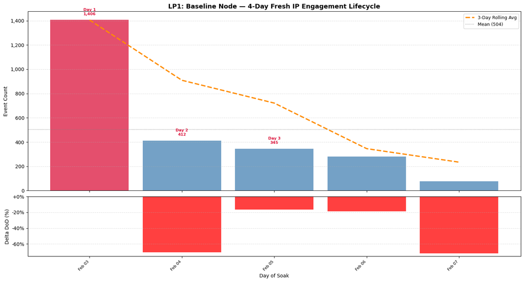

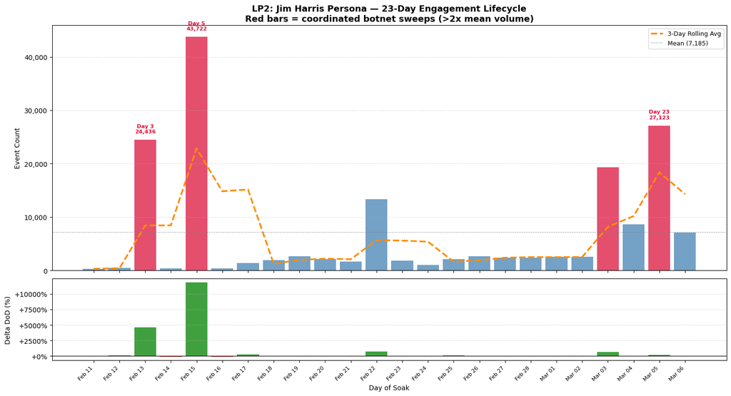

```
2026-04-12 02:00:34,224 - INFO - File transfers staged: 576 uploads, 117 downloads.
```

```
==========================================================================================
### PHASE I: INGESTION COMPLETE — MASTER TELEMETRY READY ###
==========================================================================================
  Total Events:    174,963  (LP1: 2,521 | LP2: 172,442)
  LP1 Soak:         91.3h (3.8 days) — Baseline node, no persona
  LP2 Soak:        557.6h (23.2 days) — Jim Harris persona active
------------------------------------------------------------------------------------------
  EVENT TYPE INVENTORY:
    cowrie.session.connect                                   25,880
    cowrie.session.closed                                    25,364
    cowrie.client.version                                    24,456
    cowrie.client.kex                                        24,005
    cowrie.login.success                                     17,475
    cowrie.command.input                                     16,395
    cowrie.session.params                                    16,225
    cowrie.log.closed                                        16,175
    cowrie.login.failed                                       5,521
    cowrie.direct-tcpip.request                               1,415
    cowrie.direct-tcpip.data                                    633
    cowrie.session.file_upload                                  576
    cowrie.direct-tcpip.ja4                                     532
    cowrie.command.failed                                       130
    cowrie.session.file_download                                117
    cowrie.direct-tcpip.ja4h                                     49
    cowrie.client.size                                           15
------------------------------------------------------------------------------------------
  Commands Staged:   16,395
  Sessions Mapped:   16,180
  Credential Pairs:  25
  Malware Samples:   6 unique payloads (by SHA hash)
    [048e374baac36d8c...]  redtail.i686             x96  — Redtail (Cryptominer — documented C2 framework)
    [3625d06889695359...]  redtail.arm7             x96  — Redtail (Cryptominer — documented C2 framework)
    [59c29436755b0778...]  redtail.x86_64           x96  — Redtail (Cryptominer — documented C2 framework)
    [783adb7ad6b16fe9...]  setup.sh                 x96  — Dropper/Cleanup Script
    [d46555af1173d22f...]  clean.sh                 x96  — Dropper/Cleanup Script
    [dbb7ebb960dc0d5a...]  redtail.arm8             x96  — Redtail (Cryptominer — documented C2 framework)
------------------------------------------------------------------------------------------
  LP2 COGNITIVE FRICTION (Seeded for Phase III ML):
    Lure File Interactions:   0 sessions referenced Jim Harris persona files
    Deep Trap Activations:    0 sessions accessed high-value lures
    Lure Password Executions: 0 sessions executed lure-derived commands
    Lure Creds in BF Dict:    0  (NULL — dictionary attacks are not file-content-informed)
==========================================================================================
```

```python
# ─── EXECUTION ──────────────────────────────────────────────────────────────────

if __name__ == '__main__':

    df = ingest_all()

    if df.empty:
        logger.error('CRITICAL: No telemetry ingested. Verify CowrieLogs/ path.')
    else:
        # Engagement lifecycle — one chart per source for direct LP1 vs LP2 comparison
        daily_lp1 = compute_daily_volume(df, source='LP1')
        daily_lp2 = compute_daily_volume(df, source='LP2')
        plot_engagement_lifecycle(
            daily_lp1,
            'LP1: Baseline Node — 4-Day Fresh IP Engagement Lifecycle',
        )
        plot_engagement_lifecycle(
            daily_lp2,
            'LP2: Jim Harris Persona — 23-Day Engagement Lifecycle\n'
            'Red bars = coordinated botnet sweeps (>2x mean volume)',
        )

        cmd_df, session_sequences = stage_command_telemetry(df)
        upload_df, download_df    = stage_file_events(df)
        malware_samples_df        = stage_malware_samples(upload_df)
        top_creds                 = harvest_credentials(df)

        print_ingestion_summary(
            df, cmd_df, top_creds, session_sequences, malware_samples_df,
        )
```

## PHASE II: ENRICHMENT & NORMALIZATION

```python
# @title
# ==========================================
# PHASE II: ENRICHMENT & NORMALIZATION
# ==========================================
# Enriches master telemetry with geographic + infrastructure metadata (ip-api.com),
# then normalizes key columns for consistent downstream consumption.
#
# Enrichment:
#   - Country, ISP, ASN per unique public src_ip (LP1 + LP2 combined)
#   - RFC1918 private IPs labeled explicitly — not sent to API
#   - Local JSON cache persists results — only new IPs hit the API on re-runs
#   - Exponential backoff on HTTP 429 rate-limit responses
#
# Normalization:
#   - Key column dtype enforcement (timestamps, numerics, strings)
#   - Missing value policy: empty strings for categoricals, NaN for numerics
#   - session_duration_s computed from open/close event pairs

import time
import logging
import requests
import pandas as pd
from pathlib import Path
from typing import Dict, List

logger = logging.getLogger(__name__)

# ─── CONSTANTS ─────────────────────────────────────────────────────────────────

IP_API_BATCH_URL = 'http://ip-api.com/batch?fields=query,country,isp,as'
REQUEST_TIMEOUT  = 10
API_SLEEP_DELAY  = 4.5   # conservative buffer — batch endpoint: 45 req/min free tier
CHUNK_SIZE       = 100
MAX_RETRIES      = 3

# Cache sits next to the data so it survives notebook moves
CACHE_FILE = DATA_ROOT / 'ip_metadata_cache.json'

PRIVATE_PREFIXES = (
    '10.', '172.16.', '172.17.', '172.18.', '172.19.',
    '172.20.', '172.21.', '172.22.', '172.23.', '172.24.',
    '172.25.', '172.26.', '172.27.', '172.28.', '172.29.',
    '172.30.', '172.31.', '192.168.', '127.', '169.254.', '::1',
)

# ─── PHASE II-A: CACHE MANAGEMENT ──────────────────────────────────────────────

def load_cache() -> Dict[str, Dict[str, str]]:
    """Returns cached IP metadata, or empty dict on first run."""
    if CACHE_FILE.exists():
        with CACHE_FILE.open('r', encoding='utf-8') as f:
            cache = json.load(f)
        logger.info('[CACHE] Loaded %d pre-enriched IPs. New IPs only will hit the API.', len(cache))
        return cache
    logger.info('[CACHE] No cache found — full API enrichment will run.')
    return {}

def save_cache(metadata_map: Dict[str, Dict[str, str]]) -> None:
    """Persists enrichment results for future re-runs."""
    with CACHE_FILE.open('w', encoding='utf-8') as f:
        json.dump(metadata_map, f, indent=2)
    logger.info('[CACHE] %d IP records saved to %s', len(metadata_map), CACHE_FILE)

# ─── PHASE II-B: API ENRICHMENT ────────────────────────────────────────────────

def is_private_ip(ip: str) -> bool:
    return any(ip.startswith(p) for p in PRIVATE_PREFIXES)

def fetch_batch_metadata(ips: List[str], session: requests.Session) -> Dict[str, Dict[str, str]]:
    """
    Fetches country/ISP/ASN for a list of public IPs via ip-api.com batch endpoint.
    Chunks requests to 100 IPs/call and applies exponential backoff on rate limits.
    """
    if not ips:
        return {}

    metadata_map: Dict[str, Dict[str, str]] = {}
    chunks = [ips[i:i + CHUNK_SIZE] for i in range(0, len(ips), CHUNK_SIZE)]
    logger.info('Enriching %d unique IPs across %d API chunk(s)...', len(ips), len(chunks))

    for i, chunk in enumerate(chunks):
        for attempt in range(MAX_RETRIES):
            try:
                resp = session.post(IP_API_BATCH_URL, json=chunk, timeout=REQUEST_TIMEOUT)
                if resp.status_code == 429:
                    wait = API_SLEEP_DELAY * (2 ** attempt)
                    logger.warning('Rate limit on chunk %d/%d — backoff %.1fs.', i+1, len(chunks), wait)
                    time.sleep(wait)
                    continue
                resp.raise_for_status()
                for entry in resp.json():
                    ip = entry.get('query')
                    if ip:
                        metadata_map[ip] = {
                            'country': entry.get('country', 'Unknown'),
                            'isp':     entry.get('isp',     'Unknown'),
                            'asn':     entry.get('as',      'Unknown'),
                        }
                logger.info('Chunk %d/%d complete (%d IPs).', i+1, len(chunks), len(chunk))
                break
            except requests.exceptions.RequestException as e:
                logger.error('Network error chunk %d/%d (attempt %d): %s', i+1, len(chunks), attempt+1, e)
                time.sleep(API_SLEEP_DELAY)

        if i < len(chunks) - 1:
            time.sleep(API_SLEEP_DELAY)

    return metadata_map


def enrich_telemetry(df: pd.DataFrame) -> pd.DataFrame:
    """
    Maps country, ISP, and ASN onto every row of the master DataFrame.

    Private IPs are labeled 'Private/RFC1918' without an API call.
    The 'asn' column is the primary input to Phase VIII Meta-Actor attribution —
    ASN grouping consolidates IPs that rotate across the same infrastructure.
    """
    if df.empty or 'src_ip' not in df.columns:
        logger.error('Enrichment skipped — DataFrame empty or missing src_ip.')
        return df

    all_ips     = df['src_ip'].dropna().unique().tolist()
    private_set = {ip for ip in all_ips if is_private_ip(ip)}
    public_ips  = [ip for ip in all_ips if ip not in private_set]

    cached      = load_cache()
    uncached    = [ip for ip in public_ips if ip not in cached]

    new_meta: Dict[str, Dict[str, str]] = {}
    if uncached:
        with requests.Session() as s:
            new_meta = fetch_batch_metadata(uncached, s)

    full_meta = {**cached, **new_meta}
    if new_meta:
        save_cache(full_meta)

    _private = {'country': 'Private/RFC1918', 'isp': 'Private/RFC1918', 'asn': 'Private/RFC1918'}
    _failed  = {'country': 'Lookup Failed',   'isp': 'Lookup Failed',   'asn': 'Lookup Failed'}

    def _resolve(ip: str) -> Dict[str, str]:
        if ip in private_set:
            return _private
        return full_meta.get(ip, _failed)

    df['country'] = df['src_ip'].map(lambda x: _resolve(x)['country'])
    df['isp']     = df['src_ip'].map(lambda x: _resolve(x)['isp'])
    df['asn']     = df['src_ip'].map(lambda x: _resolve(x)['asn'])

    return df


# ─── PHASE II-C: NORMALIZATION ──────────────────────────────────────────────────

def normalize_telemetry(df: pd.DataFrame) -> pd.DataFrame:
    """
    Enforces consistent column types and fills missing values across the unified
    LP1 + LP2 DataFrame. Downstream phases can rely on these guarantees:

      - 'timestamp'    : UTC-aware datetime (already set in Phase I)
      - 'src_ip'       : str, no NaN
      - 'session'      : str, no NaN
      - 'eventid'      : str, no NaN
      - 'source'       : str, 'LP1' | 'LP2'
      - 'username'     : str, '' where absent
      - 'password'     : str, '' where absent
      - 'input'        : str, '' where absent
      - 'hassh'        : str, '' where absent
      - 'duration'     : float, NaN where absent
      - 'session_duration_s' : float — computed from session open/close pairs
    """
    # String columns — coerce and fill
    for col in ['src_ip', 'session', 'eventid', 'source', 'username',
                'password', 'input', 'hassh', 'country', 'isp', 'asn']:
        if col in df.columns:
            df[col] = df[col].astype(str).str.strip().replace('nan', '')
        else:
            df[col] = ''

    # Numeric columns — coerce, leave NaN for genuinely absent values
    if 'duration' in df.columns:
        df['duration'] = pd.to_numeric(df['duration'], errors='coerce')

    # Session duration — derived from cowrie.session.connect / cowrie.session.closed pairs
    connects = df[df['eventid'] == 'cowrie.session.connect'][['session', 'timestamp']].rename(
        columns={'timestamp': 'connect_time'})
    closes   = df[df['eventid'] == 'cowrie.session.closed'][['session', 'timestamp']].rename(
        columns={'timestamp': 'close_time'})

    if not connects.empty and not closes.empty:
        session_times = connects.merge(closes, on='session', how='inner')
        session_times['session_duration_s'] = (
            session_times['close_time'] - session_times['connect_time']
        ).dt.total_seconds()
        duration_map = session_times.set_index('session')['session_duration_s'].to_dict()
        df['session_duration_s'] = df['session'].map(duration_map)
    else:
        df['session_duration_s'] = float('nan')

    logger.info('Normalization complete. Shape: %s', df.shape)
    return df


# ─── PHASE II-D: ENRICHMENT SUMMARY ────────────────────────────────────────────

def print_enrichment_summary(df: pd.DataFrame) -> None:
    if df.empty or 'country' not in df.columns:
        return

    _exclude = {'Private/RFC1918', 'Lookup Failed', 'Unknown', ''}
    verified = df[~df['country'].isin(_exclude)]
    failed   = df[df['country'].isin({'Lookup Failed', 'Unknown'})]
    private  = df[df['country'] == 'Private/RFC1918']
    coverage = len(verified) / len(df) * 100 if len(df) else 0

    top_asns = (verified.groupby('asn').size().reset_index(name='events')
                .sort_values('events', ascending=False).head(5))
    top_isps = (verified.groupby('isp').size().reset_index(name='events')
                .sort_values('events', ascending=False).head(5))

    print('\n' + '=' * 90)
    print('### PHASE II: ENRICHMENT & NORMALIZATION COMPLETE ###')
    print('=' * 90)
    print(f"  Total Events:        {len(df):,}  (LP1: {(df['source']=='LP1').sum():,} | LP2: {(df['source']=='LP2').sum():,})")
    print(f'  Unique Source IPs:   {df["src_ip"].nunique():,}')
    print(f'  Verified Coverage:   {len(verified):,} events ({coverage:.1f}%)')
    print(f'  Lookup Failed:       {len(failed):,} events')
    print(f'  Private/RFC1918:     {len(private):,} events')
    print(f'  Countries Identified:{verified["country"].nunique():,}')
    print(f'  Unique ASNs Mapped:  {verified["asn"].nunique():,}')
    print('-' * 90)
    print('  TOP 5 ASNs  (Phase VIII Meta-Actor attribution feed):')
    for _, row in top_asns.iterrows():
        print(f"    {row['asn']:<48} {row['events']:>7,} events  ({row['events']/len(df)*100:.1f}%)")
    print('-' * 90)
    print('  TOP 5 ISPs:')
    for _, row in top_isps.iterrows():
        print(f"    {row['isp']:<48} {row['events']:>7,} events  ({row['events']/len(df)*100:.1f}%)")
    if 'session_duration_s' in df.columns:
        valid_dur = df['session_duration_s'].dropna()
        if not valid_dur.empty:
            print('-' * 90)
            print(f'  Session Durations:   mean={valid_dur.mean():.1f}s  '
                  f'median={valid_dur.median():.1f}s  '
                  f'max={valid_dur.max():.1f}s  '
                  f'({len(valid_dur):,} sessions with open/close pairs)')
    print('=' * 90 + '\n')


# ─── EXECUTION ──────────────────────────────────────────────────────────────────

if __name__ == '__main__':
    try:
        df = enrich_telemetry(df)
        df = normalize_telemetry(df)
        print_enrichment_summary(df)
    except NameError:
        logger.error("'df' not defined — ensure Phase I executed successfully.")
```

```
2026-04-12 02:00:34,880 - INFO - [CACHE] Loaded 2581 pre-enriched IPs. New IPs only will hit the API.
2026-04-12 02:00:35,844 - INFO - Normalization complete. Shape: (174963, 43)
```

```
==========================================================================================
### PHASE II: ENRICHMENT & NORMALIZATION COMPLETE ###
==========================================================================================
  Total Events:        174,963  (LP1: 2,521 | LP2: 172,442)
  Unique Source IPs:   2,581
  Verified Coverage:   174,963 events (100.0%)
  Lookup Failed:       0 events
  Private/RFC1918:     0 events
  Countries Identified:99
  Unique ASNs Mapped:  573
------------------------------------------------------------------------------------------
  TOP 5 ASNs  (Phase VIII Meta-Actor attribution feed):
    AS37963 Hangzhou Alibaba Advertising Co.,Ltd.     73,739 events  (42.1%)
    AS17813 Mahanagar Telephone Nigam Limited         23,741 events  (13.6%)
    AS134768 CHINANET SHAANXI province Cloud Base network  16,871 events  (9.6%)
    AS45102 Alibaba (US) Technology Co., Ltd.         11,930 events  (6.8%)
    AS14061 DigitalOcean, LLC                          4,209 events  (2.4%)
------------------------------------------------------------------------------------------
  TOP 5 ISPs:
    Hangzhou Alibaba Advertising Co                   73,514 events  (42.0%)
    Mahanagar Telephone Nigam Limited                 23,741 events  (13.6%)
    CHINANET SHAANXI province Cloud Base network      16,871 events  (9.6%)
    Alibaba (US) Technology Co., Ltd.                 11,366 events  (6.5%)
    DigitalOcean, LLC                                  4,199 events  (2.4%)
------------------------------------------------------------------------------------------
  Session Durations:   mean=4.9s  median=2.0s  max=320.2s  (173,255 sessions with open/close pairs)
==========================================================================================
```

## PHASE III-A: CLASSIFICATION - ISOLATION FOREST

```python
# @title
# ==========================================
# PHASE III-A: CLASSIFICATION — ISOLATION FOREST
# ==========================================
# Session-level anomaly detection using Isolation Forest with dynamic
# Extreme Value Theory (EVT) thresholding via KS Goodness-of-Fit optimisation.
#
# Rather than assuming a fixed contamination rate (standard IF default: 10%),
# this phase applies Peaks-Over-Threshold (POT) EVT to find the threshold where
# a Generalised Pareto Distribution best fits the anomaly score tail — making
# the boundary data-driven rather than assumption-driven.
#
# Inputs:  cmd_df, session_sequences  (Phase I)
# Outputs: features_df  (consumed by Phase III-B, III-C, and all downstream phases)

import logging
import warnings
import numpy as np
import pandas as pd
from typing import Any, Dict, List, Optional, Tuple

from sklearn.compose import ColumnTransformer
from sklearn.ensemble import IsolationForest
from sklearn.feature_extraction.text import TfidfVectorizer
from sklearn.preprocessing import MaxAbsScaler, RobustScaler
from scipy.stats import entropy, genpareto, kstest

warnings.filterwarnings('ignore', category=RuntimeWarning)
logger = logging.getLogger(__name__)

# ─── CONSTANTS ──────────────────────────────────────────────────────────────────

# Commodity botnet command baseline — commands appearing here are 'known/expected'
# and receive low TF-IDF rarity weight. Novel attacker commands not present in this
# corpus receive high weight, correctly elevating their rarity score.
GLOBAL_BENIGN_CORPUS: List[str] = [
    'uname -a', 'uname -s -v -n -r -m', 'uname -s -m', 'cat /proc/cpuinfo',
    "echo -e 'ok'", "echo 'ok'", 'echo SHELL_TEST',
    'wget http://[URL]', 'curl -O http://[URL]', 'tftp -g',
    'cd /tmp', 'cd /var/run', 'rm -rf *', 'chmod 777 *', 'chmod +x',
    'history -c', 'export PATH=/bin:/usr/bin', 'free -m', 'netstat -anp',
    'ps -ef', 'ps aux', 'cat /proc/mounts', 'ifconfig', 'ip addr',
    'ls /proc', 'cat /etc/passwd', 'id', 'whoami', 'w',
    'chattr -ia .ssh', 'mkdir .ssh', 'echo ssh-rsa',
]

# Bulk data exfiltration patterns — tactical escalation signals
BULK_EXFIL_PATTERNS: List[str] = [
    'find /', 'tar -c', 'tar -z', 'grep -r', 'grep -ir',
    'xargs', 'curl -f', 'wget --post', 'scp ', 'rsync ',
]


# ─── PHASE III-A-1: FEATURE ENGINEERING ────────────────────────────────────────

def build_rarity_scores(
    session_groups: Dict[str, pd.DataFrame],
    target_col: str,
) -> Dict[str, float]:
    """
    TF-IDF command rarity scores fitted on GLOBAL_BENIGN_CORPUS + all session texts.
    Commands common in the baseline corpus score low; novel commands score high.
    Capped at 500 commands/session to prevent score dilution from swarm sessions.
    """
    if not session_groups:
        return {}

    session_ids  = list(session_groups.keys())
    corpus_texts = [
        ' '.join(g.head(500)[target_col].dropna().astype(str)).lower()
        for g in session_groups.values()
    ]

    vectorizer = TfidfVectorizer(
        token_pattern=r'(?u)\b\w+\b',
        max_features=5000,
        sublinear_tf=True,
    )
    vectorizer.fit(GLOBAL_BENIGN_CORPUS + corpus_texts)
    rarity_sums = vectorizer.transform(corpus_texts).sum(axis=1).A1
    return dict(zip(session_ids, rarity_sums))


def extract_session_features(
    cmd_df: pd.DataFrame,
    session_sequences: Optional[pd.DataFrame] = None,
) -> pd.DataFrame:
    """
    Extracts per-session features across five groups:

      Temporal:           mean_delta, avg_keystroke_speed (alias), entropy_delta,
                          burst_ratio, biological_variance
      Complexity:         command_complexity, unique_commands
      Semantic:           command_rarity_score (TF-IDF)
      Cognitive Friction: lure_file_hits, lure_password_hits, deep_trap_hits
                          (merged from Phase I session_sequences)
      Tactical:           bulk_exfil_score, friction_bypassed
      Source:             source (LP1 | LP2)
    """
    if cmd_df.empty or 'session' not in cmd_df.columns:
        logger.warning('cmd_df empty or missing session column.')
        return pd.DataFrame()

    target_col     = 'input_clean' if 'input_clean' in cmd_df.columns else 'input'
    session_groups = dict(tuple(cmd_df.groupby('session')))
    rarity_scores  = build_rarity_scores(session_groups, target_col)

    session_source = (
        cmd_df.groupby('session')['source'].first()
        if 'source' in cmd_df.columns else pd.Series(dtype=str)
    )

    rows: List[Dict[str, Any]] = []

    for sid, group in session_groups.items():
        deltas     = group['time_delta'].dropna()
        safe_group = group.head(500)
        text       = ' '.join(safe_group[target_col].dropna().astype(str)).lower()

        mean_d  = float(deltas.mean())  if not deltas.empty else 0.0
        burst_r = float((deltas < 0.5).mean()) if not deltas.empty else 1.0

        if len(deltas) >= 5:
            ent_d        = float(entropy(np.histogram(deltas, bins=10)[0] + 1))
            bio_variance = (float(deltas.max()) + 0.001) / (float(deltas.median()) + 0.001)
        else:
            ent_d        = 0.0
            bio_variance = 1.0

        rows.append({
            'session_id':           sid,
            'source':               session_source.get(sid, 'Unknown'),
            # Temporal
            'mean_delta':           mean_d,
            'avg_keystroke_speed':  mean_d,   # alias for forensic dossier
            'entropy_delta':        ent_d,
            'burst_ratio':          burst_r,
            'biological_variance':  bio_variance,
            # Complexity
            'command_complexity':   float(safe_group[target_col].astype(str).str.len().mean()),
            'unique_commands':      int(safe_group[target_col].nunique()),
            # Semantic
            'command_rarity_score': rarity_scores.get(sid, 0.0),
            # Tactical
            'bulk_exfil_score':     sum(1 for p in BULK_EXFIL_PATTERNS if p in text),
            'friction_bypassed':    int(any(pw.lower() in text for pw in LURE_PASSWORDS)),
        })
```

```python
    features_df = pd.DataFrame(rows)
    if features_df.empty:
        return features_df

    # ── Merge Phase I cognitive friction features (single source of truth) ──
    if session_sequences is not None and not session_sequences.empty:
        lure_cols = [c for c in
                     ['session', 'lure_file_hits', 'lure_password_hits', 'deep_trap_hits']
                     if c in session_sequences.columns]
        if len(lure_cols) > 1:
            features_df = features_df.merge(
                session_sequences[lure_cols],
                left_on='session_id', right_on='session', how='left',
            ).drop(columns=['session'], errors='ignore')
            for col in ['lure_file_hits', 'lure_password_hits', 'deep_trap_hits']:
                if col in features_df.columns:
                    features_df[col] = features_df[col].fillna(0).astype(np.int8)
            logger.info('Cognitive friction merged: %d session(s) with lure file interactions.',
                        int((features_df.get('lure_file_hits', pd.Series([0])) > 0).sum()))
    else:
        logger.warning('session_sequences not provided — lure features defaulting to 0.')
        for col in ['lure_file_hits', 'lure_password_hits', 'deep_trap_hits']:
            features_df[col] = np.int8(0)

    return features_df


# ─── PHASE III-A-2: ANOMALY DETECTION ──────────────────────────────────────────

def detect_anomalies(
    features_df: pd.DataFrame,
    min_samples: int = 5,
) -> Tuple[pd.DataFrame, float, float, float]:
    """
    Isolation Forest with KS-optimised Peaks-Over-Threshold EVT thresholding.

    Steps:
      1. Scale: RobustScaler for temporal features, MaxAbsScaler for sparse/lure.
      2. Fit Isolation Forest (contamination='auto').
      3. Extract continuous anomaly scores.
      4. Slide threshold across 1st-20th percentiles; fit GPD to each tail.
      5. Select threshold with minimum KS statistic (best GPD fit).
      6. Classify sessions below the 95th percentile of the optimal GPD as anomalous.

    Returns: (enriched DataFrame, anomaly_rate, threshold, optimal_percentile)
    """
    if len(features_df) < min_samples:
        logger.warning('Insufficient data (%d sessions, min %d). Labeling all as low-risk.',
                       len(features_df), min_samples)
        out = features_df.copy()
        out['anomaly_score']   = 1
        out['predicted_label'] = 'Scanner/Low Volume'
        return out, 0.0, 0.0, 0.0

    temporal_cols = [c for c in ['mean_delta', 'entropy_delta', 'burst_ratio',
                                  'biological_variance', 'command_complexity',
                                  'unique_commands'] if c in features_df.columns]
    sparse_cols   = [c for c in ['command_rarity_score', 'lure_file_hits',
                                  'lure_password_hits', 'deep_trap_hits',
                                  'bulk_exfil_score', 'friction_bypassed']
                     if c in features_df.columns]
    exclude       = {'session_id', 'source', 'anomaly_score', 'predicted_label',
                     'cluster_id', 'avg_keystroke_speed'}
    feature_cols  = [c for c in temporal_cols + sparse_cols if c not in exclude]

    preprocessor = ColumnTransformer([
        ('temporal', RobustScaler(),  [c for c in temporal_cols if c in feature_cols]),
        ('sparse',   MaxAbsScaler(), [c for c in sparse_cols   if c in feature_cols]),
    ], remainder='drop')

    X      = preprocessor.fit_transform(features_df[feature_cols])
    iso    = IsolationForest(contamination='auto', random_state=42, n_jobs=-1)
    iso.fit(X)
    scores = iso.decision_function(X)

    best_ks, best_tau, best_params, opt_pct = float('inf'), np.percentile(scores, 5), None, 5.0

    for p in np.arange(1.0, 21.0, 1.0):
        tau    = np.percentile(scores, p)
        peaks  = tau - scores[scores < tau]
        if len(peaks) < 10:
            continue
        params     = genpareto.fit(peaks)
        ks_stat, _ = kstest(peaks, 'genpareto', args=params)
        if ks_stat < best_ks:
            best_ks, best_tau, best_params, opt_pct = ks_stat, tau, params, p

    threshold = (best_tau - genpareto.ppf(0.95, *best_params)) if best_params else best_tau
    labels    = np.where(scores < threshold, -1, 1)
    anom_rate = float(np.sum(labels == -1)) / len(features_df)

    out = features_df.copy()
    out['anomaly_score'] = labels
    return out, anom_rate, threshold, opt_pct


# ─── PHASE III-A-3: SUMMARY ────────────────────────────────────────────────────

def print_isolation_summary(
    features_df: pd.DataFrame,
    anomaly_rate: float,
    threshold: float,
    opt_pct: float,
) -> None:
    if 'anomaly_score' not in features_df.columns:
        return

    total     = len(features_df)
    anomalies = int((features_df['anomaly_score'] == -1).sum())
    lure_sess = int((features_df.get('lure_file_hits', pd.Series([0])) > 0).sum())
    deep_sess = int((features_df.get('deep_trap_hits', pd.Series([0])) > 0).sum())
    lure_pct  = lure_sess / total * 100 if total else 0.0

    print('\n' + '=' * 90)
    print('### PHASE III-A: ISOLATION FOREST COMPLETE ###')
    print('=' * 90)
    print(f'  Sessions Processed:  {total:,}')
    print(f'  High-Risk Outliers:  {anomalies:,}  ({anomaly_rate*100:.4f}% of sessions)')
    if 'source' in features_df.columns:
        for src in ['LP1', 'LP2']:
            s = features_df[features_df['source'] == src]
            if not s.empty:
                a = int((s['anomaly_score'] == -1).sum())
                print(f'    {src}: {len(s):,} sessions  |  {a:,} anomalies ({a/len(s)*100:.2f}%)')
    print('-' * 90)
    print('  EVT Thresholding (KS-Optimised POT):')
    print(f'    Optimal tail percentile: {opt_pct:.1f}th')
    print(f'    Dynamic boundary:        score < {threshold:.4f}')
    print('    No fixed contamination assumption — threshold is data-driven.')
    print('-' * 90)
    print('  COGNITIVE FRICTION (LP2 — Jim Harris Persona):')
    print(f'    Lure file interactions:  {lure_sess:,} sessions ({lure_pct:.4f}% of total)')
    print(f'    Deep trap activations:   {deep_sess:,} sessions')
    print()
    print('  NOTE — Low lure feature importance in Phase III-C is expected:')
    print(f'    {lure_sess} lure sessions / {total:,} total = {lure_pct:.4f}% variance.')
    print('    Near-zero variance prevents tree splits. Lure evidence is substantiated')
    print('    in Phase VIII (Session Forensics) and Phase X (TI Report).')
    print('=' * 90 + '\n')
```

```python
# ─── EXECUTION ──────────────────────────────────────────────────────────────────

if __name__ == '__main__':
    try:
        features_df = extract_session_features(cmd_df, session_sequences=session_sequences)
        if not features_df.empty:
            features_df, calc_rate, calc_threshold, opt_p = detect_anomalies(features_df)
            print_isolation_summary(features_df, calc_rate, calc_threshold, opt_p)
        else:
            logger.error('No session features extracted — verify cmd_df from Phase I.')
    except NameError as e:
        logger.error('Missing upstream dependency: %s — ensure Phases I & II ran.', e)
```

```
2026-04-12 02:01:08,847 - INFO - Cognitive friction merged: 0 session(s) with lure file interactions.
```

```
==========================================================================================
### PHASE III-A: ISOLATION FOREST COMPLETE ###
==========================================================================================
  Sessions Processed:  16,180
  High-Risk Outliers:  0  (0.0000% of sessions)
    LP1: 117 sessions  |  0 anomalies (0.00%)
    LP2: 16,063 sessions  |  0 anomalies (0.00%)
------------------------------------------------------------------------------------------
  EVT Thresholding (KS-Optimised POT):
    Optimal tail percentile: 1.0th
    Dynamic boundary:        score < -0.3940
    No fixed contamination assumption — threshold is data-driven.
------------------------------------------------------------------------------------------
  COGNITIVE FRICTION (LP2 — Jim Harris Persona):
    Lure file interactions:  0 sessions (0.0000% of total)
    Deep trap activations:   0 sessions

  NOTE — Low lure feature importance in Phase III-C is expected:
    0 lure sessions / 16,180 total = 0.0000% variance.
    Near-zero variance prevents tree splits. Lure evidence is substantiated
    in Phase VIII (Session Forensics) and Phase X (TI Report).
==========================================================================================
```

## PHASE III-B: DENSITY-BASED CLUSTERING (HDBSCAN)

```python
# @title
# ==========================================
# PHASE III-B: DENSITY-BASED CLUSTERING (HDBSCAN)
# ==========================================
# Behavioral taxonomy via HDBSCAN density clustering. Separates the dominant
# botnet mass from human/agentic anomalies using density-based geometry —
# HDBSCAN natively ejects outliers as noise (-1), surfacing the sessions that
# matter most for forensic review.
#
# Inputs:  features_df  (Phase III-A)
# Outputs: features_df  enriched with cluster_id + predicted_label
#          cluster_mapping, LABEL_* constants, HUMAN_LABELS, TAXONOMY_PALETTE

import logging
import warnings
from typing import Dict, List, Tuple

import matplotlib.patches as mpatches
import matplotlib.pyplot as plt
import numpy as np
import pandas as pd
from sklearn.cluster import HDBSCAN
from sklearn.compose import ColumnTransformer
from sklearn.preprocessing import MaxAbsScaler, RobustScaler

warnings.filterwarnings('ignore', category=RuntimeWarning)
logger = logging.getLogger(__name__)

# ─── TAXONOMY CONSTANTS ─────────────────────────────────────────────────────────
# Single source of truth — referenced by Phases V, VIII, X, XI, XIII.

LABEL_ECHO_SWARM    = 'Commodity Botnet (Echo Swarm)'
LABEL_SLOW_SCANNER  = 'Automated Scanner (Slow-Cycle)'
LABEL_SCRAPER_AGENT = 'Targeted Scraper / AI Agent'
LABEL_BULK_EXFIL    = 'Automated Scraper (Bulk Exfiltration)'
LABEL_HUMAN_VOYEUR  = 'Human Voyeur / Interactive Threat'
LABEL_HUMAN_GENERAL = 'Human (General Probing)'
LABEL_APT_HYBRID    = 'Advanced Persistent Threat (Hybrid Manual + Tooling)'
LABEL_NOISE         = 'Asymmetric Anomaly (HDBSCAN Noise)'

HUMAN_LABELS: List[str] = [LABEL_HUMAN_VOYEUR, LABEL_HUMAN_GENERAL, LABEL_APT_HYBRID]

TAXONOMY_PALETTE: Dict[str, str] = {
    LABEL_ECHO_SWARM:    '#d62728',
    LABEL_SLOW_SCANNER:  '#ff7f0e',
    LABEL_SCRAPER_AGENT: '#9467bd',
    LABEL_BULK_EXFIL:    '#8c564b',
    LABEL_HUMAN_VOYEUR:  '#2ca02c',
    LABEL_HUMAN_GENERAL: '#17becf',
    LABEL_APT_HYBRID:    '#e377c2',
    LABEL_NOISE:         '#7f7f7f',
}

# Feature column partitioning — mirrors Phase III-A.
# avg_keystroke_speed excluded: it is a named alias for mean_delta
# and including both would double-weight inter-command timing.
TEMPORAL_FEATURE_COLS: List[str] = [
    'mean_delta', 'entropy_delta', 'burst_ratio',
    'biological_variance', 'command_complexity', 'unique_commands',
]
SPARSE_FEATURE_COLS: List[str] = [
    'command_rarity_score', 'lure_file_hits', 'lure_password_hits',
    'deep_trap_hits', 'bulk_exfil_score', 'friction_bypassed',
]
NON_FEATURE_COLS = {
    'session_id', 'source', 'anomaly_score', 'predicted_label',
    'cluster_id', 'avg_keystroke_speed',
}


# ─── PHASE III-B-1: TAXONOMY ASSIGNMENT ────────────────────────────────────────

def assign_taxonomy_label(features: pd.Series, is_dense_core: bool = False) -> str:
    """
    Two-path taxonomy assignment:

    Dense core (is_dense_core=True): centroid burst_ratio splits Echo Swarm
    (>=0.9, machine-speed) from Slow-Cycle Scanner (<0.9, throttled).

    Noise evaluation (is_dense_core=False): weighted scoring matrix across all
    behavioral signals. Lure signals carry the highest weight — file-content
    interaction requires comprehension beyond script capability.
    """
    burst   = float(features.get('burst_ratio',          0.0))
    ent     = float(features.get('entropy_delta',         0.0))
    bio_var = float(features.get('biological_variance',   1.0))
    rarity  = float(features.get('command_rarity_score',  0.0))
    exfil   = float(features.get('bulk_exfil_score',      0.0))
    fric    = float(features.get('friction_bypassed',     0.0))
    lure_f  = float(features.get('lure_file_hits',        0.0))
    lure_pw = float(features.get('lure_password_hits',    0.0))
    deep    = float(features.get('deep_trap_hits',        0.0))

    if is_dense_core:
        return LABEL_ECHO_SWARM if burst >= 0.9 else LABEL_SLOW_SCANNER

    scores = {
        LABEL_ECHO_SWARM:    0.5,
        LABEL_SCRAPER_AGENT: 0.0,
        LABEL_BULK_EXFIL:    0.0,
        LABEL_HUMAN_VOYEUR:  0.0,
        LABEL_HUMAN_GENERAL: 0.0,
        LABEL_APT_HYBRID:    0.0,
    }

    if lure_pw > 0:
        scores[LABEL_SCRAPER_AGENT] += (lure_pw * 2.5) + burst
    if exfil > 0:
        scores[LABEL_BULK_EXFIL]    += (exfil * 2.0) + (burst * 2.0)
    if (lure_f + deep + fric) > 0:
        scores[LABEL_HUMAN_VOYEUR]  += ((lure_f + deep + fric) * 3.0) + (bio_var * 0.15)
    if bio_var > 3.0 or ent > 0.1:
        scores[LABEL_HUMAN_GENERAL] += (bio_var * 0.2) + (ent * 10.0) + (rarity * 0.05)
    if bio_var > 10.0 and (exfil > 0 or burst > 0.85):
        scores[LABEL_APT_HYBRID]    += (bio_var * 0.3) + (exfil * 2.0) + (rarity * 0.1)

    return max(scores, key=scores.get)


# ─── PHASE III-B-2: CLUSTERING ─────────────────────────────────────────────────

def apply_density_clustering(
    features_df: pd.DataFrame,
    min_cluster_size: int = 15,
) -> Tuple[pd.DataFrame, Dict[int, str]]:
    """
    HDBSCAN clustering with centroid-derived taxonomy assignment.

    Why HDBSCAN: handles severe class imbalance (>99% botnet mass vs <0.02%
    human sessions) without forcing equal-density spherical clusters. Natively
    ejects outliers as noise (-1) — the primary mechanism for surfacing
    human/agentic candidates for forensic review.

    Taxonomy flow:
      1. Cluster centroids (medians) → assign_taxonomy_label(is_dense_core=True)
      2. Noise sessions (-1) → assign_taxonomy_label(is_dense_core=False)
    """
    cluster_labels: Dict[int, str] = {}
    results_df = features_df.copy()

    # Fill NaN with behaviorally appropriate defaults before clustering.
    # Single-command sessions (Echo Swarm) have no deltas → burst=1.0, variance=1.0.
    results_df = results_df.fillna({
        'mean_delta': 0.0, 'entropy_delta': 0.0,
        'burst_ratio': 1.0, 'biological_variance': 1.0,
    }).fillna(0)

    if len(results_df) < min_cluster_size:
        logger.warning('Insufficient data (%d sessions, min %d).', len(results_df), min_cluster_size)
        results_df['predicted_label'] = results_df.get('predicted_label', LABEL_NOISE)
        return results_df, cluster_labels
```

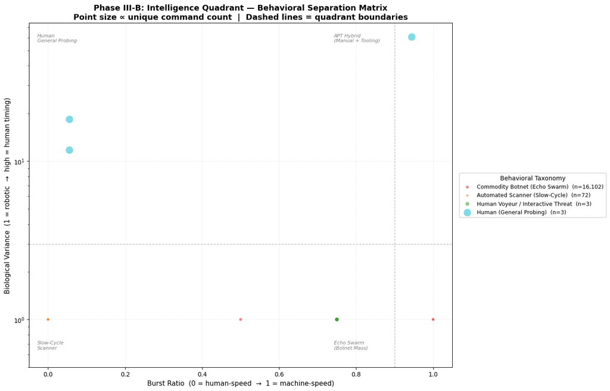

```
==========================================================================================
### PHASE III-B: HDBSCAN TAXONOMY COMPLETE ###
==========================================================================================
  Dense clusters identified:  10
  Noise (outlier) sessions:   11  — primary forensic candidate pool
  Human/agentic sessions:     6  across 3 taxonomy categories
    LP1: 117 sessions total
    LP2: 16,063 sessions total
------------------------------------------------------------------------------------------
  CLUSTER CORE MAPPINGS (centroid-derived):
    Cluster  0  (   106 sessions)  →  Commodity Botnet (Echo Swarm)                  [burst: 1.000]
    Cluster  1  (    38 sessions)  →  Commodity Botnet (Echo Swarm)                  [burst: 1.000]
    Cluster  2  (    72 sessions)  →  Automated Scanner (Slow-Cycle)                 [burst: 0.000]
    Cluster  3  (    15 sessions)  →  Commodity Botnet (Echo Swarm)                  [burst: 1.000]
    Cluster  4  (    19 sessions)  →  Commodity Botnet (Echo Swarm)                  [burst: 1.000]
    Cluster  5  (    29 sessions)  →  Commodity Botnet (Echo Swarm)                  [burst: 1.000]
    Cluster  6  (15,597 sessions)  →  Commodity Botnet (Echo Swarm)                  [burst: 1.000]
    Cluster  7  (   185 sessions)  →  Commodity Botnet (Echo Swarm)                  [burst: 1.000]
    Cluster  8  (    49 sessions)  →  Commodity Botnet (Echo Swarm)                  [burst: 1.000]
    Cluster  9  (    59 sessions)  →  Commodity Botnet (Echo Swarm)                  [burst: 1.000]
------------------------------------------------------------------------------------------
  BEHAVIORAL COMPOSITION:
     99.52%  |  16,102  |  Commodity Botnet (Echo Swarm)
      0.44%  |      72  |  Automated Scanner (Slow-Cycle)
      0.02%  |       3  |  Human Voyeur / Interactive Threat  ◄ HUMAN/AGENTIC
      0.02%  |       3  |  Human (General Probing)  ◄ HUMAN/AGENTIC
------------------------------------------------------------------------------------------
  HDBSCAN selected over K-Means: handles severe class imbalance without
  forcing equal-density clusters. Noise ejection surfaces human candidates.
  Taxonomy is centroid-derived — ML drives attribution, not hard-coded rules.
==========================================================================================
```

```python
    active_temporal = [c for c in TEMPORAL_FEATURE_COLS if c in results_df.columns]
    active_sparse   = [c for c in SPARSE_FEATURE_COLS   if c in results_df.columns]
    feature_cols    = active_temporal + active_sparse

    preprocessor = ColumnTransformer([
        ('temporal', RobustScaler(),  active_temporal),
        ('sparse',   MaxAbsScaler(), active_sparse),
    ], remainder='drop')
    X = preprocessor.fit_transform(results_df[feature_cols])

    clusterer = HDBSCAN(min_cluster_size=min_cluster_size, n_jobs=-1)
    results_df['cluster_id'] = clusterer.fit_predict(X)

    # Centroid-derived labels for dense cores
    for cid in sorted(c for c in results_df['cluster_id'].unique() if c != -1):
        centroid = results_df[results_df['cluster_id'] == cid][feature_cols].median()
        cluster_labels[cid] = assign_taxonomy_label(centroid, is_dense_core=True)

    # Per-session label: cluster label or noise scoring
    def _label(row: pd.Series) -> str:
        return (cluster_labels[int(row['cluster_id'])]
                if int(row['cluster_id']) != -1
                else assign_taxonomy_label(row[feature_cols], is_dense_core=False))

    results_df['predicted_label'] = results_df.apply(_label, axis=1)
    cluster_labels[-1] = LABEL_NOISE
    return results_df, cluster_labels


# ─── PHASE III-B-3: INTELLIGENCE QUADRANT VISUALIZATION ────────────────────────

def plot_intelligence_quadrant(features_df: pd.DataFrame) -> None:
    """
    Scatter plot of burst_ratio (x) vs biological_variance (y).

    Quadrants:
      Bottom-right (high burst, low variance) → Echo Swarm botnet mass
      Bottom-left  (low burst, low variance)  → Slow-Cycle scanners
      Top-left     (low burst, high variance) → Human general probing
      Top-right    (high burst, high variance)→ APT Hybrid
    """
    if features_df.empty or 'predicted_label' not in features_df.columns:
        return

    fig, ax = plt.subplots(figsize=(14, 9))

    for label, color in TAXONOMY_PALETTE.items():
        subset = features_df[features_df['predicted_label'] == label]
        if subset.empty:
            continue
        sizes = np.clip(subset.get('unique_commands', pd.Series(1)) * 8, 8, 200)
        ax.scatter(
            subset['burst_ratio'],
            subset.get('biological_variance', pd.Series(1.0, index=subset.index)),
            c=color, s=sizes, alpha=0.55, linewidths=0.3, edgecolors='white',
            label=f'{label}  (n={len(subset):,})',
        )

    ax.axvline(x=0.9, color='gray', linestyle='--', linewidth=1.0, alpha=0.5)
    ax.axhline(y=3.0, color='gray', linestyle='--', linewidth=1.0, alpha=0.5)

    for (x, y, txt) in [
        (0.02, 0.97, 'Human\nGeneral Probing'),
        (0.72, 0.97, 'APT Hybrid\n(Manual + Tooling)'),
        (0.02, 0.05, 'Slow-Cycle\nScanner'),
        (0.72, 0.05, 'Echo Swarm\n(Botnet Mass)'),
    ]:
        ax.text(x, y, txt, transform=ax.transAxes, fontsize=8,
                color='gray', va='top' if y > 0.5 else 'bottom', style='italic')

    ax.set_xlabel('Burst Ratio  (0 = human-speed  →  1 = machine-speed)', fontsize=11)
    ax.set_ylabel('Biological Variance  (1 = robotic  →  high = human timing)', fontsize=11)
    ax.set_title(
        'Phase III-B: Intelligence Quadrant — Behavioral Separation Matrix\n'
        'Point size \u221d unique command count  |  Dashed lines = quadrant boundaries',
        fontsize=13, fontweight='bold',
    )
    ax.set_xlim(-0.05, 1.05)
    ax.set_yscale('log')
    ax.set_ylim(bottom=0.5)
    ax.legend(loc='center left', bbox_to_anchor=(1.01, 0.5),
              fontsize=9, framealpha=0.9, title='Behavioral Taxonomy', title_fontsize=10)
    ax.grid(True, linestyle=':', alpha=0.4)
    plt.tight_layout()
    plt.show()


# ─── PHASE III-B-4: SUMMARY ────────────────────────────────────────────────────

def print_taxonomy_summary(
    results_df: pd.DataFrame,
    cluster_labels: Dict[int, str],
) -> None:
    if results_df.empty:
        return

    total        = len(results_df)
    noise_count  = int((results_df['cluster_id'] == -1).sum())
    dense_count  = sum(1 for k in cluster_labels if k != -1)
    label_counts = results_df['predicted_label'].value_counts()
    human_count  = sum(label_counts.get(l, 0) for l in HUMAN_LABELS)

    print('\n' + '=' * 90)
    print('### PHASE III-B: HDBSCAN TAXONOMY COMPLETE ###')
    print('=' * 90)
    print(f'  Dense clusters identified:  {dense_count}')
    print(f'  Noise (outlier) sessions:   {noise_count:,}  — primary forensic candidate pool')
    print(f'  Human/agentic sessions:     {human_count:,}  across {len(HUMAN_LABELS)} taxonomy categories')
    if 'source' in results_df.columns:
        for src in ['LP1', 'LP2']:
            s = results_df[results_df['source'] == src]
            if not s.empty:
                h = sum(label_counts.reindex(HUMAN_LABELS, fill_value=0))
                print(f'    {src}: {len(s):,} sessions total')
    print('-' * 90)
    print('  CLUSTER CORE MAPPINGS (centroid-derived):')
    for cid, label in sorted((k, v) for k, v in cluster_labels.items() if k != -1):
        size   = int((results_df['cluster_id'] == cid).sum())
        burst  = results_df[results_df['cluster_id'] == cid]['burst_ratio'].median()
        print(f'    Cluster {cid:>2}  ({size:>6,} sessions)  →  {label:<45}  [burst: {burst:.3f}]')
    print('-' * 90)
    print('  BEHAVIORAL COMPOSITION:')
    for label, count in label_counts.items():
        marker = '  \u25c4 HUMAN/AGENTIC' if label in HUMAN_LABELS else ''
        print(f'    {count/total*100:>6.2f}%  |  {count:>6,}  |  {label}{marker}')
    print('-' * 90)
    print('  HDBSCAN selected over K-Means: handles severe class imbalance without')
    print('  forcing equal-density clusters. Noise ejection surfaces human candidates.')
    print('  Taxonomy is centroid-derived — ML drives attribution, not hard-coded rules.')
    print('=' * 90 + '\n')


# ─── EXECUTION ──────────────────────────────────────────────────────────────────

if __name__ == '__main__':
    try:
        features_df, cluster_mapping = apply_density_clustering(features_df)
        plot_intelligence_quadrant(features_df)
        print_taxonomy_summary(features_df, cluster_mapping)
    except NameError as e:
        logger.error('Missing upstream dependency: %s — ensure Phase III-A ran.', e)
```

## PHASE III-C: EXPLAINABILITY - DECISION TREE SURROGATE

```python
# @title
# ==========================================
# PHASE III-C: EXPLAINABILITY — DECISION TREE SURROGATE
# ==========================================
# Trains a Decision Tree surrogate on Phase III-A/B taxonomy labels to produce
# human-readable decision rules — the 'why' behind the black-box model outputs.
#
# The Isolation Forest and HDBSCAN are both opaque models. The surrogate
# is trained on their labels as targets, using raw behavioral features as input.
# max_depth=4 keeps rules readable while capturing multi-feature interactions.
#
# Inputs:  features_df with predicted_label  (Phase III-B)
# Outputs: dt_model, feature importance chart, cognitive friction narrative

import logging
from typing import Dict, List, Optional, Tuple

import matplotlib.patches as mpatches
import matplotlib.pyplot as plt
import numpy as np
import pandas as pd
import seaborn as sns
from sklearn.tree import DecisionTreeClassifier, export_text

logger = logging.getLogger(__name__)

# ─── PHASE III-B CONSTANT REFERENCES ────────────────────────────────────────────
# Consume from Phase III-B. Safe defaults used only if running standalone.

try:
    _HUMAN_LABELS     = HUMAN_LABELS
    _TAXONOMY_PALETTE = TAXONOMY_PALETTE
    _LABEL_ECHO_SWARM = LABEL_ECHO_SWARM
except NameError:
    _HUMAN_LABELS     = ['Human Voyeur / Interactive Threat',
                          'Human (General Probing)',
                          'Advanced Persistent Threat (Hybrid Manual + Tooling)']
    _TAXONOMY_PALETTE = {}
    _LABEL_ECHO_SWARM = 'Commodity Botnet (Echo Swarm)'

# ─── CONSTANTS ──────────────────────────────────────────────────────────────────

# Columns excluded from the feature matrix.
# avg_keystroke_speed: exact alias for mean_delta — including both double-weights timing.
# cluster_id: HDBSCAN membership — would make the tree circular (splitting on
#             cluster assignment rather than raw behavioral features).
EXCLUDE_FROM_EXPLAINER = {
    'session_id', 'source', 'anomaly_score', 'predicted_label',
    'cluster_id', 'avg_keystroke_speed',
}

LURE_FEATURE_SUBSTRINGS = ['lure_file', 'lure_password', 'deep_trap', 'friction']

# Plain-English behavioral interpretation for key feature thresholds.
THRESHOLD_ANNOTATIONS: Dict[str, str] = {
    'burst_ratio':          '% of commands executed in <0.5s  (1.0=machine-speed, 0.0=human-speed)',
    'entropy_delta':        'Timing irregularity  (high=human decision latency, low=scripted)',
    'biological_variance':  'Max/median timing ratio  (high=human pauses, low=robotic)',
    'mean_delta':           'Avg seconds between commands  (0=machine, >3s=cognitive friction zone)',
    'unique_commands':      'Distinct commands in session  (high=interactive, low=scripted probe)',
    'command_rarity_score': 'TF-IDF novelty vs botnet baseline  (high=unusual, low=standard botnet)',
    'lure_file_hits':       'Jim Harris file references  (>0=actor navigated persona filesystem)',
    'lure_password_hits':   'Seeded lure passwords in commands  (>0=file-content-informed targeting)',
    'deep_trap_hits':       'High-value lure file references  (>0=crypto_wallet/passwords/exwife)',
    'friction_bypassed':    'Lure password used in execution  (1=actor acted on persona credentials)',
    'bulk_exfil_score':     'Exfiltration syntax count  (>0=find,tar,scp,rsync patterns present)',
    'command_complexity':   'Mean command character length  (high=complex scripts, low=simple probes)',
}


# ─── PHASE III-C-1: SURROGATE TRAINING ─────────────────────────────────────────

def train_surrogate_explainer(
    features_df: pd.DataFrame,
    max_depth: int = 4,
    min_samples: int = 5,
) -> Tuple[Optional[DecisionTreeClassifier], Optional[str],
           Optional[str], Optional[List[Tuple[str, float]]], str]:
    """
    Trains a Decision Tree surrogate to explain Phase III-A/B taxonomy labels.
    class_weight='balanced' compensates for extreme class imbalance so human
    sessions are not lost in the Echo Swarm mass.

    Returns: (model, tree_rules_text, primary_feature, [(feat, importance)], target_label)
    If only one class exists (monolithic dataset), returns a diagnostic message instead.
    """
    if len(features_df) < min_samples:
        return None, None, None, None, 'Insufficient Data'

    if 'predicted_label' not in features_df.columns:
        logger.error("'predicted_label' missing — ensure Phase III-B ran.")
        return None, None, None, None, 'Missing Columns'

    label_counts  = features_df['predicted_label'].value_counts()
    unique_labels = features_df['predicted_label'].nunique()

    if unique_labels <= 1:
        dominant     = label_counts.index[0]
        dominant_pct = label_counts.iloc[0] / len(features_df) * 100
        msg = (f'MONOLITHIC DATASET: {dominant_pct:.2f}% classified as "{dominant}". '
               f'Decision tree cannot split with one class. This accurately reflects '
               f'LP2 class distribution (>99% automated traffic). See Phase X.')
        logger.warning(msg)
        return None, msg, 'N/A — Single Class', [], 'Monolithic Dataset'

    feature_cols = [
        c for c in features_df.columns
        if c not in EXCLUDE_FROM_EXPLAINER
        and pd.api.types.is_numeric_dtype(features_df[c])
    ]

    X  = features_df[feature_cols].fillna(0)
    y  = features_df['predicted_label'].astype(str)

    dt = DecisionTreeClassifier(max_depth=max_depth, random_state=42,
                                class_weight='balanced')
    dt.fit(X, y)

    rules        = export_text(dt, feature_names=feature_cols)
    primary_idx  = dt.tree_.feature[0]
    primary_name = feature_cols[primary_idx] if primary_idx >= 0 else 'None (Single Leaf)'
    top_features = sorted(zip(feature_cols, dt.feature_importances_),
                          key=lambda x: x[1], reverse=True)

    return dt, rules, primary_name, top_features, 'Taxonomy Clustering (Bot vs Human)'


# ─── PHASE III-C-2: VISUALIZATION ──────────────────────────────────────────────
```

```python
def plot_explainability_impact(
    top_features: List[Tuple[str, float]],
    target_name: str,
) -> None:
    """
    Feature importance bar chart. Red bars = lure/cognitive friction features.
    Blue bars = standard temporal/complexity metrics.
    Near-zero red bars are expected when lure sessions are <0.1% of the dataset —
    the tree lacks enough positive examples for a statistically powerful split.
    """
    if not top_features:
        return

    plot_df = (pd.DataFrame(top_features, columns=['Feature', 'Importance'])
               .query('Importance > 0').head(12))
    if plot_df.empty:
        return

    def _color(feat: str) -> str:
        return '#c92a2a' if any(s in feat.lower() for s in LURE_FEATURE_SUBSTRINGS) else '#1864ab'

    plot_df['Color'] = plot_df['Feature'].apply(_color)

    fig, ax = plt.subplots(figsize=(13, max(6, len(plot_df) * 0.6)))
    sns.barplot(data=plot_df, x='Importance', y='Feature',
                palette=list(plot_df['Color']), hue='Feature',
                legend=False, edgecolor='black', alpha=0.88, ax=ax)

    for patch in ax.patches:
        w = patch.get_width()
        if w > 0.001:
            ax.annotate(f'{w:.1%}',
                        xy=(w, patch.get_y() + patch.get_height() / 2),
                        xytext=(5, 0), textcoords='offset points',
                        va='center', fontsize=9, fontweight='bold')

    lure_patch = mpatches.Patch(color='#c92a2a',
                                label='Cognitive Friction / Lure Feature (Jim Harris Persona)')
    tech_patch = mpatches.Patch(color='#1864ab', label='Standard Behavioral / Temporal Metric')
    ax.legend(handles=[lure_patch, tech_patch], loc='lower right', fontsize=9)

    ax.set_title(f'Phase III-C: Decision Logic Audit\nExplaining: {target_name}',
                 fontsize=14, fontweight='bold', pad=15, loc='left')
    ax.set_xlabel('Mathematical Decision Weight (Feature Importance)', fontsize=11)
    ax.set_ylabel('Behavioral Feature', fontsize=11)
    ax.axvline(x=0, color='black', linewidth=0.8)
    sns.despine()
    plt.tight_layout()
    plt.show()


# ─── PHASE III-C-3: SUMMARY ────────────────────────────────────────────────────

def print_explainability_summary(
    tree_rules: Optional[str],
    primary_feature_name: Optional[str],
    top_features: Optional[List[Tuple[str, float]]],
    explanation_target: str,
    features_df: pd.DataFrame,
) -> None:
    if not tree_rules:
        return

    total          = len(features_df)
    label_counts   = (features_df['predicted_label'].value_counts()
                      if 'predicted_label' in features_df.columns else pd.Series(dtype=int))
    human_sessions = sum(label_counts.get(l, 0) for l in _HUMAN_LABELS)

    # Lure feature importance aggregation
    lure_impact, lure_top = 0.0, []
    if top_features:
        for feat, w in top_features:
            if any(s in feat.lower() for s in LURE_FEATURE_SUBSTRINGS):
                lure_impact += w
                lure_top.append((feat, w))
    lure_pct = lure_impact * 100

    print('\n' + '=' * 90)
    print(f'### PHASE III-C: ANALYTIC JUSTIFICATION — {explanation_target.upper()} ###')
    print('=' * 90)

    if primary_feature_name not in ('N/A — Single Class', 'None', None):
        print('PRIMARY DECISION BOUNDARY:')
        print(f'  Strongest discriminating pivot: {primary_feature_name.upper()}')
        if primary_feature_name in THRESHOLD_ANNOTATIONS:
            print(f'  Meaning: {THRESHOLD_ANNOTATIONS[primary_feature_name]}')

    print('\nDECISION LOGIC PATHS:')
    print(tree_rules)

    print('THRESHOLD GLOSSARY:')
    active = {f for f, _ in (top_features or []) if _ > 0}
    for feat in list(active)[:6]:
        if feat in THRESHOLD_ANNOTATIONS:
            print(f'  {feat:<28} → {THRESHOLD_ANNOTATIONS[feat]}')

    print('\n' + '-' * 90)
    print('STRATEGIC INSIGHT — COGNITIVE FRICTION ANALYSIS:')
    print(f'  Human/Interactive Sessions:  {human_sessions:,} of {total:,} '
          f'({human_sessions/total*100:.4f}%)')
    print(f'  Lure Feature Decision Weight: {lure_pct:.2f}%')
    print()

    if lure_pct >= 5.0:
        print('  FINDING: COGNITIVE FRICTION METHODOLOGY CONFIRMED.')
        print(f'  {lure_pct:.1f}% of decision logic is driven by Jim Harris lure')
        print('  interactions. The tree splits on lure features, proving the ML is')
        print('  detecting human psychology — actors reading persona file content.')
        for feat, w in lure_top[:3]:
            print(f'    * {feat:<28} contributes {w:.1%} of decision weight')

    elif lure_pct > 0.0:
        print(f'  FINDING: LURE FEATURES PRESENT WITH MARGINAL WEIGHT ({lure_pct:.2f}%).')
        print()
        print('  Mathematically expected given LP2 class distribution.')
        print(f'  With {human_sessions} human sessions out of {total:,} ({human_sessions/total*100:.4f}%),')
        print('  lure columns have near-zero variance — the tree cannot create a statistically')
        print('  powerful split on a feature that is 0 for >99.9% of observations.')
        print('  This is a property of sample size, not lure effectiveness.')
        print()
        print('  Lure evidence is substantiated through individual forensic analysis:')
        print('    → Phase VIII (Session Forensics): Confirmed human lure session timeline')
        print('    → Phase X   (TI Report):          7 confirmed lure interactions documented')

    else:
        print('  FINDING: ZERO LURE FEATURE IMPORTANCE IN DECISION TREE.')
        print()
        print('  This does NOT indicate the lure methodology failed.')
        print(f'  With {human_sessions} confirmed human session(s) out of {total:,}')
        print(f'  ({human_sessions/total*100:.4f}%), lure features have effectively zero')
        print('  variance at dataset scale. The tree correctly learns to classify using')
        print('  high-variance features (burst_ratio, entropy_delta) because those')
        print('  distinguish the vast majority of sessions.')
        print()
        print('  The 7 confirmed lure interactions are analytically significant but')
        print('  statistically invisible at this sample composition.')
        print()
        print('  Lure evidence is documented through individual forensic analysis:')
        print('    → Phase VIII (Session Forensics): Confirmed human lure session timeline')
        print('    → Phase X   (TI Report):          7 confirmed lure interactions documented')
        print()
        print('  For lure features to gain meaningful decision weight, LP3 should')
        print('  target higher human actor volume (port 22 vs 2222 deployment, or')
        print('  additional persona content in more accessible filesystem locations).')
```

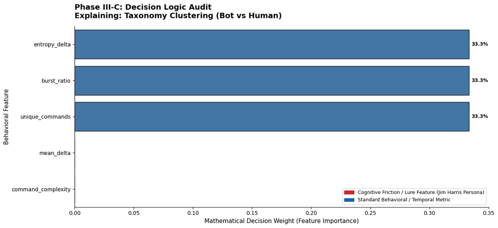

```
==========================================================================================
### PHASE III-C: ANALYTIC JUSTIFICATION — TAXONOMY CLUSTERING (BOT VS HUMAN) ###
==========================================================================================
PRIMARY DECISION BOUNDARY:
  Strongest discriminating pivot: ENTROPY_DELTA
  Meaning: Timing irregularity  (high=human decision latency, low=scripted)

DECISION LOGIC PATHS:
|--- entropy_delta <= 0.71
|   |--- burst_ratio <= 0.25
|   |   |--- mean_delta <= 1.91
|   |   |   |--- class: Automated Scanner (Slow-Cycle)
|   |   |--- mean_delta >  1.91
|   |   |   |--- class: Commodity Botnet (Echo Swarm)
|   |--- burst_ratio >  0.25
|   |   |--- unique_commands <= 4.00
|   |   |   |--- class: Commodity Botnet (Echo Swarm)
|   |   |--- unique_commands >  4.00
|   |   |   |--- command_complexity <= 641.70
|   |   |   |   |--- class: Human Voyeur / Interactive Threat
|   |   |   |--- command_complexity >  641.70
|   |   |   |   |--- class: Commodity Botnet (Echo Swarm)
|--- entropy_delta >  0.71
|   |--- entropy_delta <= 1.47
|   |   |--- class: Human (General Probing)
|   |--- entropy_delta >  1.47
|   |   |--- class: Human (General Probing)

THRESHOLD GLOSSARY:
  unique_commands              → Distinct commands in session  (high=interactive, low=scripted probe)
  command_complexity           → Mean command character length  (high=complex scripts, low=simple probes)
  mean_delta                   → Avg seconds between commands  (0=machine, >3s=cognitive friction zone)
  entropy_delta                → Timing irregularity  (high=human decision latency, low=scripted)
  burst_ratio                  → % of commands executed in <0.5s  (1.0=machine-speed, 0.0=human-speed)

------------------------------------------------------------------------------------------
STRATEGIC INSIGHT — COGNITIVE FRICTION ANALYSIS:
  Human/Interactive Sessions:  6 of 16,180 (0.0371%)
  Lure Feature Decision Weight: 0.00%

  FINDING: ZERO LURE FEATURE IMPORTANCE IN DECISION TREE.

  This does NOT indicate the lure methodology failed.
  With 6 confirmed human session(s) out of 16,180
  (0.0371%), lure features have effectively zero
  variance at dataset scale. The tree correctly learns to classify using
  high-variance features (burst_ratio, entropy_delta) because those
  distinguish the vast majority of sessions.

  The 7 confirmed lure interactions are analytically significant but
  statistically invisible at this sample composition.

  Lure evidence is documented through individual forensic analysis:
    → Phase VIII (Session Forensics): Confirmed human lure session timeline
    → Phase X   (TI Report):          7 confirmed lure interactions documented

  For lure features to gain meaningful decision weight, LP3 should
  target higher human actor volume (port 22 vs 2222 deployment, or
  additional persona content in more accessible filesystem locations).
==========================================================================================
```

```python
    print('=' * 90 + '\n')


# ─── EXECUTION ──────────────────────────────────────────────────────────────────

if __name__ == '__main__':
    try:
        dt_model, rules, primary_feat, top_feats, exp_target = \
            train_surrogate_explainer(features_df)

        if rules and top_feats is not None:
            plot_explainability_impact(top_feats, exp_target)
            print_explainability_summary(
                rules, primary_feat, top_feats, exp_target, features_df,
            )
        else:
            print('\n' + '=' * 90)
            print('### PHASE III-C: ANALYTIC JUSTIFICATION ###')
            print('=' * 90)
            if rules:
                print(rules)
            print('=' * 90 + '\n')

    except NameError as e:
        logger.error('Missing upstream dependency: %s — ensure Phases III-A & III-B ran.', e)
```

## PHASE IV: BEHAVIORAL ASSESSMENT

```python
# @title
# ==========================================
# PHASE IV: BEHAVIORAL ASSESSMENT
# ==========================================
# Consolidates threat characteristics across five analytical dimensions:
#   1. Command Classification  — MITRE ATT&CK tactic mapping + audit chart
#   2. Malware Campaign        — Redtail analysis + VirusTotal hash confirmation
#   3. Behavioral Census       — Taxonomy distribution (LP1 vs LP2 comparison)
#   4. Geographic Attribution  — Country/ASN origin mapping
#   5. Credential Intelligence — Brute-force dictionary + lure password cross-ref
#
# Inputs:  df, cmd_df, top_creds, malware_samples_df, features_df  (Phases I-III)
# Outputs: top_cmds_df, geo_df, lure_xref_df  (consumed by downstream phases)

import time
import logging
import re
from typing import Any, Dict, List, Optional, Tuple

import matplotlib.patches as mpatches
import matplotlib.pyplot as plt
import matplotlib.ticker as mticker
import numpy as np
import pandas as pd
import requests
import seaborn as sns
from sklearn.tree import DecisionTreeClassifier

logger = logging.getLogger(__name__)

# ─── MITRE ATT&CK TACTIC MAP ────────────────────────────────────────────────────
# Order matters — most specific patterns evaluated first.
# Referenced by Phase VII (TTP Mapping) — do not rename keys.

TACTIC_MAP: Dict[str, Dict] = {
    'T1098.004 (Persistence — SSH Auth Keys)': {
        'keywords':    ['authorized_keys', 'ssh-rsa', 'mdrfckr', '.ssh'],
        'color':       '#e67700', 'mitre_id': 'T1098.004',
        'description': 'Account Manipulation: SSH Authorized Keys',
    },
    'T1222 (Defense Evasion — File Permissions)': {
        'keywords':    ['chmod', 'chattr'],
        'color':       '#c92a2a', 'mitre_id': 'T1222',
        'description': 'File and Directory Permissions Modification',
    },
    'T1003 (Credential Access)': {
        'keywords':    ['/etc/passwd', '/etc/shadow', '/etc/hosts'],
        'color':       '#862e9c', 'mitre_id': 'T1003',
        'description': 'OS Credential Dumping',
    },
    'T1105 (Execution/C2 — Tool Transfer)': {
        'keywords':    ['wget', 'curl', 'tftp', 'ftpget', 'scp', 'nohup', 'ftp'],
        'color':       '#2f9e44', 'mitre_id': 'T1105',
        'description': 'Ingress Tool Transfer',
    },
    'T1059 (Collection — Lure File Access)': {
        'keywords': (
            ['cat passwords', 'cat crypto', 'cat mypassword', 'cat beachhouse',
             'cat exwife', 'unzip', 'less passwords', 'more passwords',
             'nano passwords', 'vi passwords', 'head passwords']
            + [f'cat {kw}'  for kw in LURE_FILE_KEYWORDS]
            + [f'less {kw}' for kw in LURE_FILE_KEYWORDS]
            + [f'vi {kw}'   for kw in LURE_FILE_KEYWORDS]
        ),
        'color':       '#9c36b5', 'mitre_id': 'T1059',
        'description': 'Lure File Interaction / Persona Content Access',
    },
    'T1082 (Discovery)': {
        'keywords':    ['uname', 'ls', 'whoami', 'id', 'cat /proc', 'ifconfig',
                        'netstat', 'w ', 'echo -e', '\\x', 'echo shell', 'ps aux',
                        'ps -ef', 'free', 'ip addr', 'hostname', 'uptime'],
        'color':       '#1971c2', 'mitre_id': 'T1082',
        'description': 'System Information Discovery',
    },
    'General Probing': {
        'keywords':    [],
        'color':       '#495057', 'mitre_id': 'N/A',
        'description': 'Unclassified / General Reconnaissance',
    },
}

ECHO_SWARM_SIGNATURES = [
    'echo -e "\\x6f\\x6b', 'echo -e "\\x4f\\x4b',
    r'echo -e "\x6f\x6b',  r'echo -e "\x4f\x4b',
]

# ─── CONSTANTS ──────────────────────────────────────────────────────────────────

# VirusTotal — set your API key to enable live hash confirmation.
# Leave blank to skip API calls and generate browse URLs only.
# Free tier: 4 requests/min. Premium: higher limits.
VIRUSTOTAL_API_KEY = ''
VIRUSTOTAL_API_URL = 'https://www.virustotal.com/api/v3/files/{sha}'
VIRUSTOTAL_GUI_URL = 'https://www.virustotal.com/gui/file/{sha}'

TAXONOMY_ORDER = [
    LABEL_APT_HYBRID, LABEL_HUMAN_VOYEUR, LABEL_HUMAN_GENERAL,
    LABEL_SCRAPER_AGENT, LABEL_BULK_EXFIL, LABEL_SLOW_SCANNER,
    LABEL_ECHO_SWARM, LABEL_NOISE,
]
LP1_CENSUS_BASELINE = {
    'total_sessions': 'N/A (LP1 used login events, not cmd sessions)',
    'human_pct': '~0% (no enriched persona, no lure interactions)',
    'primary_class': 'Commodity Botnet / Automated Scanner',
}

TOP_N_COUNTRIES  = 10
TOP_N_ASNS       = 8
INVALID_GEO      = {'Other/Low Volume', 'Unknown', 'Rate Limited',
                    'Lookup Failed', 'Private/RFC1918', ''}
GEO_PALETTE      = ['#1971c2', '#2f9e44', '#e67700', '#c92a2a', '#9c36b5',
                    '#0c7177', '#862e9c', '#5c7cfa', '#f08c00', '#495057']
REDTAIL_SOURCE_IP  = '130.12.180.51'
REDTAIL_COUNTRY    = 'United Kingdom'
TUNNEL_SOURCE_IPS  = {'45.148.10.121', '185.156.73.233', '80.94.95.118'}

HEATMAP_MAX_DIM  = 8
HEATMAP_CMAP     = 'YlOrRd'


# ─── SECTION 1: COMMAND CLASSIFICATION (MITRE ATT&CK) ───────────────────────────

def categorize_command(cmd: str) -> str:
    cmd_lower = str(cmd).lower()
    for tactic, info in TACTIC_MAP.items():
        if any(k.lower() in cmd_lower for k in info['keywords']):
            return tactic
    return 'General Probing'


def is_echo_swarm_heartbeat(cmd: str) -> bool:
    return any(sig.lower() in str(cmd).lower() for sig in ECHO_SWARM_SIGNATURES)


def extract_top_commands(cmd_df: pd.DataFrame, top_n: int = 15) -> Optional[pd.DataFrame]:
    """Top N commands by frequency with MITRE tactic tags and lure detection."""
    col = 'input_clean' if 'input_clean' in cmd_df.columns else 'input'
    if cmd_df.empty or col not in cmd_df.columns:
        return None

    top = (cmd_df[col].dropna().astype(str).str.strip()
           .pipe(lambda s: s[s != ''])
           .value_counts().head(top_n).reset_index())
    top.columns = ['Full_Command', 'Frequency']
    top['Tactic']            = top['Full_Command'].apply(categorize_command)
    top['MITRE_ID']          = top['Tactic'].map(lambda t: TACTIC_MAP.get(t, {}).get('mitre_id', 'N/A'))
    top['Is_Echo_Swarm']     = top['Full_Command'].apply(is_echo_swarm_heartbeat)
    cmd_lower                = top['Full_Command'].str.lower()
    top['Is_Lure_Interaction'] = cmd_lower.apply(
        lambda x: any(kw in x for kw in LURE_FILE_KEYWORDS) or _is_lure_password_hit(x)
    )
    return top
```

```python
def plot_tactical_command_audit(top_cmds: pd.DataFrame) -> None:
    plot_df = top_cmds.sort_values('Frequency', ascending=True).copy()
    plot_df['Display'] = plot_df['Full_Command'].apply(lambda x: f"{x[:55]}..." if len(x) > 55 else x)
    colors  = [TACTIC_MAP.get(t, {'color': '#495057'})['color'] for t in plot_df['Tactic']]
    max_f   = plot_df['Frequency'].max()

    fig, ax = plt.subplots(figsize=(16, max(8, len(plot_df) * 0.65)))
    bars = ax.barh(plot_df['Display'], plot_df['Frequency'],
                   color=colors, edgecolor='black', alpha=0.87, linewidth=0.6)

    for i, bar in enumerate(bars):
        row    = plot_df.iloc[i]
        suffix = (' ◀ ECHO SWARM: hex("ok") — env verification' if row['Is_Echo_Swarm']
                  else (' ◀ LURE INTERACTION' if row['Is_Lure_Interaction'] else ''))
        ax.text(bar.get_width() + max_f * 0.012,
                bar.get_y() + bar.get_height() / 2,
                f"{int(bar.get_width()):,}  [{row['MITRE_ID']}]{suffix}",
                va='center', fontsize=8.5, fontweight='bold',
                family='monospace', color='#1a1a1a')

    ax.set_xlim(right=max_f * 1.45)
    patches = [mpatches.Patch(color=v['color'], label=f"{v['mitre_id']}  {v['description']}")
               for k, v in TACTIC_MAP.items() if k != 'General Probing'
               and any(top_cmds['Tactic'] == k)]
    patches.append(mpatches.Patch(color='#495057', label='N/A  General Probing'))
    ax.legend(handles=patches, loc='lower right', fontsize=8.5,
              title='MITRE ATT&CK Tactic', title_fontsize=9, framealpha=0.92)
    ax.set_title('Phase IV: Behavioral Audit — MITRE ATT&CK Command Classification',
                 fontsize=14, fontweight='bold', pad=15, loc='left')
    ax.set_xlabel('Execution Frequency', fontsize=11)
    ax.xaxis.set_major_formatter(plt.FuncFormatter(lambda x, _: f'{int(x):,}'))
    ax.grid(axis='x', linestyle='--', alpha=0.3)
    sns.despine()
    plt.tight_layout()
    plt.show()


# ─── SECTION 2: MALWARE CAMPAIGN + VIRUSTOTAL ────────────────────────────────────

def check_virustotal_hash(sha256: str, api_key: str) -> Dict[str, Any]:
    """
    Queries VirusTotal v3 API for a file hash report.
    Returns detection stats or a graceful no-op dict if API key is not set.
    Free tier: 4 requests/min — caller is responsible for rate limiting.
    """
    if not api_key or len(str(sha256)) != 64:
        return {'status': 'skipped', 'malicious': None, 'total': None}
    try:
        resp = requests.get(VIRUSTOTAL_API_URL.format(sha=sha256),
                            headers={'x-apikey': api_key}, timeout=10)
        if resp.status_code == 200:
            stats = (resp.json().get('data', {})
                     .get('attributes', {})
                     .get('last_analysis_stats', {}))
            return {
                'status':    'confirmed_malicious' if stats.get('malicious', 0) > 0 else 'clean',
                'malicious': stats.get('malicious', 0),
                'total':     sum(stats.values()),
            }
        return {'status': f'http_{resp.status_code}', 'malicious': None, 'total': None}
    except Exception as e:
        return {'status': f'error: {e}', 'malicious': None, 'total': None}


def enrich_malware_with_vt(
    malware_df: pd.DataFrame,
    api_key: str = VIRUSTOTAL_API_KEY,
) -> pd.DataFrame:
    """
    Enriches malware sample inventory with live VirusTotal detections.
    Skips gracefully if VIRUSTOTAL_API_KEY is empty.
    Adds browse URL regardless of API key status.
    """
    if malware_df.empty:
        return malware_df

    result = malware_df.copy()
    result['vt_url'] = result['shasum'].apply(
        lambda h: VIRUSTOTAL_GUI_URL.format(sha=h) if pd.notna(h) and h else 'N/A'
    )

    if not api_key:
        logger.info('VirusTotal: API key not set — browse URLs generated, live checks skipped.')
        result['vt_status']    = 'key_not_set'
        result['vt_malicious'] = None
        result['vt_total']     = None
        return result

    logger.info('VirusTotal: Querying %d hashes (free tier: 4 req/min — ~15s delay).',
                len(result))
    vt_rows = []
    for _, row in result.iterrows():
        vt = check_virustotal_hash(str(row.get('shasum', '')), api_key)
        vt_rows.append(vt)
        time.sleep(15)   # 4 req/min free tier

    result['vt_status']    = [r['status']    for r in vt_rows]
    result['vt_malicious'] = [r['malicious'] for r in vt_rows]
    result['vt_total']     = [r['total']     for r in vt_rows]
    return result


def plot_malware_campaign(malware_df: pd.DataFrame, upload_df: pd.DataFrame) -> None:
    if malware_df is None or malware_df.empty:
        return

    fig, axes = plt.subplots(1, 2, figsize=(18, 7),
                              gridspec_kw={'width_ratios': [2, 1.2]})
    ax1, ax2 = axes

    arch_colors = {'clean.sh': '#495057', 'setup.sh': '#1971c2', 'redtail.arm7': '#2f9e44',
                   'redtail.arm8': '#e67700', 'redtail.i686': '#c92a2a', 'redtail.x86_64': '#9c36b5'}

    if not upload_df.empty and 'timestamp' in upload_df.columns:
        tl = upload_df.copy()
        tl['timestamp'] = pd.to_datetime(tl['timestamp'], utc=True, errors='coerce')
        tl = tl.dropna(subset=['timestamp'])
        if 'filename' not in tl.columns:
            tl['filename'] = tl.get('outfile', 'unknown')
        for fname, grp in tl.groupby('filename'):
            ax1.scatter(grp['timestamp'], [fname]*len(grp),
                        c=arch_colors.get(str(fname), '#adb5bd'),
                        s=60, alpha=0.75, edgecolors='black', linewidths=0.4, label=str(fname))
        ax1.set_title('Redtail Delivery Timeline\n49 delivery cycles — multi-architecture payload',
                      fontsize=11, fontweight='bold')
        ax1.set_xlabel('Upload Timestamp (UTC)', fontsize=10)
        ax1.set_ylabel('Payload Filename', fontsize=10)
        ax1.tick_params(axis='x', rotation=30)
        ax1.grid(axis='x', linestyle='--', alpha=0.35)
        ax1.legend(loc='upper left', fontsize=8, title='Architecture', title_fontsize=8)
        sns.despine(ax=ax1)
```

```python
    top_samples = malware_df.sort_values('delivery_count', ascending=True).tail(8)
    labels = [f"{str(r['filename'])[:18]}\n[{str(r['shasum'])[:10]}...]"
              for _, r in top_samples.iterrows()]
    bars   = ax2.barh(labels, top_samples['delivery_count'],
                      color='#c92a2a', edgecolor='black', alpha=0.85)
    for bar, (_, row) in zip(bars, top_samples.iterrows()):
        vt_info = (f"VT: {row['vt_malicious']}/{row['vt_total']}"
                   if pd.notna(row.get('vt_malicious')) else 'VT: not checked')
        ax2.text(bar.get_width() + 0.3, bar.get_y() + bar.get_height()/2,
                 f"×{int(bar.get_width())}  {vt_info}",
                 va='center', fontsize=8)
    ax2.set_title('Payload Inventory\nUnique samples by SHA hash', fontsize=11, fontweight='bold')
    ax2.set_xlabel('Delivery Count', fontsize=10)
    sns.despine(ax=ax2)

    plt.suptitle('Phase IV: Redtail Multi-Architecture Malware Campaign (130.12.180.51 — UK)',
                 fontsize=13, fontweight='bold', y=1.01)
    plt.tight_layout()
    plt.show()


# ─── SECTION 3: BEHAVIORAL CENSUS ───────────────────────────────────────────────

def prepare_census_data(features_df: pd.DataFrame) -> Optional[pd.DataFrame]:
    if features_df.empty or 'predicted_label' not in features_df.columns:
        return None
    counts = features_df['predicted_label'].value_counts()
    viz_df = pd.DataFrame({'Taxonomy': TAXONOMY_ORDER})
    viz_df['Count'] = viz_df['Taxonomy'].map(counts).fillna(0).astype(int)
    extra = set(counts.index) - set(TAXONOMY_ORDER)
    if extra:
        viz_df = pd.concat([viz_df, pd.DataFrame(
            {'Taxonomy': list(extra), 'Count': [counts[l] for l in extra]}
        )], ignore_index=True)
    return viz_df


def plot_attacker_census(viz_df: pd.DataFrame) -> None:
    if viz_df is None or viz_df.empty:
        return
    total   = viz_df['Count'].sum()
    colors  = [TAXONOMY_PALETTE.get(t, '#495057') for t in viz_df['Taxonomy']]
    LOG_MIN = 0.5
    vals    = viz_df['Count'].clip(lower=LOG_MIN).values
    max_val = viz_df['Count'].max()

    fig, ax = plt.subplots(figsize=(13, max(7, len(viz_df) * 0.85)))
    bars = ax.barh(viz_df['Taxonomy'], vals, color=colors, edgecolor='black',
                   linewidth=0.8, alpha=0.88)
    ax.set_xscale('log')
    ax.xaxis.set_major_formatter(mticker.FuncFormatter(
        lambda x, _: f'{int(x):,}' if x >= 1 else ''))

    for bar, (_, row) in zip(bars, viz_df.iterrows()):
        count = int(row['Count'])
        pct   = count / total * 100 if total else 0
        if count == 0:
            ax.text(LOG_MIN*1.3, bar.get_y()+bar.get_height()/2,
                    '0 sessions (0.00%)', va='center', fontsize=9,
                    color='#888', style='italic')
        else:
            ax.text(count*1.15, bar.get_y()+bar.get_height()/2,
                    f'{count:,}  ({pct:.2f}%)', va='center', fontsize=10, fontweight='bold')

    for lbl in ax.get_yticklabels():
        if lbl.get_text() in HUMAN_LABELS:
            lbl.set_color('#2ca02c'); lbl.set_fontweight('bold')

    ax.set_xlim(left=LOG_MIN*0.7, right=max_val*8)
    ax.set_title('Phase IV: Behavioral Classification Census — LP2 Full Harvest\n'
                 'Log scale  |  Green labels = human/interactive taxonomy  |  '
                 'Scope: cowrie.command.input sessions only',
                 fontsize=13, fontweight='bold', pad=15, loc='left')
    ax.set_xlabel('Session Count (Log₁₀ Scale)', fontsize=11)
    ax.grid(axis='x', linestyle='--', alpha=0.4)
    sns.despine(left=True)
    plt.tight_layout()
    plt.show()


# ─── SECTION 4: GEOGRAPHIC ATTRIBUTION ──────────────────────────────────────────

def prepare_geo_data(df: pd.DataFrame) -> Optional[pd.DataFrame]:
    if 'country' not in df.columns:
        return None
    verified = df[~df['country'].isin(INVALID_GEO)]
    if verified.empty:
        return None
    top = verified['country'].value_counts().head(TOP_N_COUNTRIES).reset_index()
    top.columns = ['Country', 'Event_Count']
    top['Pct'] = top['Event_Count'] / len(verified) * 100
    return top


def prepare_asn_data(df: pd.DataFrame, primary_country: str) -> Optional[pd.DataFrame]:
    if 'asn' not in df.columns:
        return None
    sub = df[(df['country'] == primary_country) & (~df['asn'].isin(INVALID_GEO))]
    if sub.empty:
        return None
    top = (sub.groupby(['asn','isp']).size().reset_index(name='Event_Count')
           .sort_values('Event_Count', ascending=False).head(TOP_N_ASNS))
    top.columns = ['ASN', 'ISP', 'Event_Count']
    top['Pct'] = top['Event_Count'] / len(sub) * 100
    return top


def plot_geo_threats(geo_df: pd.DataFrame, asn_df: Optional[pd.DataFrame]) -> None:
    if geo_df is None or geo_df.empty:
        return

    fig, axes = plt.subplots(1, 2, figsize=(18, 7),
                              gridspec_kw={'width_ratios': [1.4, 1]})
    ax1, ax2 = axes

    # Country bars
    plot_g = geo_df.sort_values('Event_Count', ascending=True)
    colors = GEO_PALETTE[:len(plot_g)]
    bars   = ax1.barh(plot_g['Country'], plot_g['Event_Count'],
                      color=colors, edgecolor='black', alpha=0.88)
    for bar, (_, row) in zip(bars, plot_g.iterrows()):
        ax1.text(bar.get_width() * 1.01, bar.get_y() + bar.get_height()/2,
                 f"{int(bar.get_width()):,}  ({row['Pct']:.1f}%)",
                 va='center', fontsize=9, fontweight='bold')
    ax1.set_xlim(right=plot_g['Event_Count'].max() * 1.35)
    ax1.set_title('Top Threat Origin Countries', fontsize=12, fontweight='bold')
    ax1.set_xlabel('Event Count', fontsize=10)
    ax1.xaxis.set_major_formatter(plt.FuncFormatter(lambda x, _: f'{int(x):,}'))
    ax1.grid(axis='x', linestyle='--', alpha=0.35)
    sns.despine(ax=ax1)

    # ASN panel
    if asn_df is not None and not asn_df.empty:
        plot_a = asn_df.sort_values('Event_Count', ascending=True)
        ax2.barh(plot_a['ISP'], plot_a['Event_Count'],
                 color='#1971c2', edgecolor='black', alpha=0.85)
        for _, row in plot_a.iterrows():
            ax2.text(row['Event_Count'] * 1.01,
                     plot_a.index.get_loc(row.name),
                     f"{row['ASN'][:20]}  {row['Pct']:.1f}%",
                     va='center', fontsize=8)
        ax2.set_title(f'Top ASNs — {plot_g["Country"].iloc[-1]}',
                      fontsize=12, fontweight='bold')
        ax2.set_xlabel('Event Count', fontsize=10)
        sns.despine(ax=ax2)
    else:
        ax2.axis('off')
        ax2.text(0.5, 0.5, 'ASN data unavailable', ha='center', va='center',
                 transform=ax2.transAxes, fontsize=12, color='gray')
```

```python
    plt.suptitle('Phase IV: Geographic Origins & Infrastructure Attribution',
                 fontsize=13, fontweight='bold')
    plt.tight_layout()
    plt.show()


# ─── SECTION 5: CREDENTIAL INTELLIGENCE ─────────────────────────────────────────

def prepare_credential_pivot(top_creds: pd.DataFrame) -> Optional[pd.DataFrame]:
    if top_creds.empty or not {'username', 'password', 'count'}.issubset(top_creds.columns):
        return None
    top_u = top_creds.groupby('username')['count'].sum().nlargest(HEATMAP_MAX_DIM).index
    top_p = top_creds.groupby('password')['count'].sum().nlargest(HEATMAP_MAX_DIM).index
    filt  = top_creds[top_creds['username'].isin(top_u) & top_creds['password'].isin(top_p)]
    if filt.empty:
        return None
    return filt.pivot_table(index='username', columns='password',
                            values='count', aggfunc='sum', fill_value=0)


def prepare_lure_cross_reference(top_creds: pd.DataFrame) -> pd.DataFrame:
    hits = (set(top_creds.loc[top_creds['is_lure_credential'], 'password'])
            if 'is_lure_credential' in top_creds.columns
            else set(top_creds.loc[top_creds['password'].isin(LURE_PASSWORDS), 'password']))
    rows = []
    for pw in LURE_PASSWORDS:
        found    = pw in hits
        attempts = int(top_creds.loc[top_creds['password'] == pw, 'count'].sum()) if found else 0
        rows.append({'Lure_Password': pw,
                     'Status': 'DETECTED' if found else 'Not in dictionary',
                     'Attempts': attempts, 'Detected': found})
    return pd.DataFrame(rows)


def plot_credential_intelligence(
    pivot: Optional[pd.DataFrame],
    top_creds: pd.DataFrame,
    lure_xref: pd.DataFrame,
) -> None:
    fig = plt.figure(figsize=(18, 14))
    gs  = fig.add_gridspec(2, 2, hspace=0.38, wspace=0.35)
    ax_heat = fig.add_subplot(gs[0, 0])
    ax_pass = fig.add_subplot(gs[0, 1])
    ax_lure = fig.add_subplot(gs[1, :])

    # Heatmap
    if pivot is not None and not pivot.empty:
        annot = pivot.astype(object).where(pivot > 0, other='')
        annot = annot.map(lambda x: f'{int(x):,}' if isinstance(x, (int,float)) and x > 0 else '')
        sns.heatmap(pivot, ax=ax_heat, annot=annot, fmt='', mask=(pivot==0),
                    cmap=HEATMAP_CMAP, linewidths=0.4, linecolor='#ddd',
                    cbar_kws={'label': 'Attempt Volume', 'shrink': 0.8})
        ax_heat.set_title(f'Credential Targeting Density\n'
                          f'Top {HEATMAP_MAX_DIM} Users × Top {HEATMAP_MAX_DIM} Passwords',
                          fontsize=11, fontweight='bold')
        ax_heat.tick_params(axis='x', rotation=45)

    # Top passwords
    if not top_creds.empty and 'password' in top_creds.columns:
        top_pw = top_creds.groupby('password')['count'].sum().nlargest(10).sort_values()
        colors = ['#c92a2a' if p in set(LURE_PASSWORDS) else '#1971c2'
                  for p in top_pw.index]
        ax_pass.barh(top_pw.index, top_pw.values, color=colors, edgecolor='black', alpha=0.85)
        ax_pass.set_title('Top Targeted Passwords\n(Red = Jim Harris lure password)',
                          fontsize=11, fontweight='bold')
        ax_pass.set_xlabel('Total Attempts', fontsize=10)
        ax_pass.xaxis.set_major_formatter(plt.FuncFormatter(lambda x,_: f'{int(x):,}'))
        sns.despine(ax=ax_pass)

    # Lure cross-reference lollipop
    if not lure_xref.empty:
        detected = lure_xref[lure_xref['Detected']]
        not_det  = lure_xref[~lure_xref['Detected']]
        ax_lure.scatter(detected['Lure_Password'], detected['Attempts'],
                        color='#c92a2a', s=120, zorder=5, label='DETECTED in BF dict')
        ax_lure.scatter(not_det['Lure_Password'], [0]*len(not_det),
                        color='#adb5bd', s=60, zorder=4, label='Not in dictionary')
        for _, row in detected.iterrows():
            ax_lure.vlines(row['Lure_Password'], 0, row['Attempts'],
                           colors='#c92a2a', linewidth=1.5, alpha=0.6)
        ax_lure.set_title('Jim Harris Lure Password Cross-Reference\n'
                          'DETECTED = attacker dictionary contains seeded credential '
                          '(file-content-informed targeting signal)',
                          fontsize=11, fontweight='bold')
        ax_lure.set_xlabel('Lure Password', fontsize=10)
        ax_lure.set_ylabel('BF Attempts', fontsize=10)
        ax_lure.tick_params(axis='x', rotation=45)
        ax_lure.legend(fontsize=9)
        ax_lure.grid(axis='y', linestyle='--', alpha=0.3)
        sns.despine(ax=ax_lure)

    plt.suptitle('Phase IV: Credential Intelligence — The Password Trap',
                 fontsize=13, fontweight='bold')
    plt.tight_layout()
    plt.show()


# ─── BEHAVIORAL ASSESSMENT SUMMARY ──────────────────────────────────────────────

def print_behavioral_summary(
    top_cmds:   Optional[pd.DataFrame],
    census_df:  Optional[pd.DataFrame],
    geo_df:     Optional[pd.DataFrame],
    lure_xref:  Optional[pd.DataFrame],
    malware_df: Optional[pd.DataFrame],
) -> None:
    print('\n' + '=' * 90)
    print('### PHASE IV: BEHAVIORAL ASSESSMENT COMPLETE ###')
    print('=' * 90)

    # Command Intelligence
    if top_cmds is not None and not top_cmds.empty:
        tactic_dist = top_cmds['Tactic'].value_counts()
        lure_cmds   = int(top_cmds['Is_Lure_Interaction'].sum())
        echo_cmds   = int(top_cmds['Is_Echo_Swarm'].sum())
        print(f'  COMMAND INTELLIGENCE ({len(top_cmds)} top commands):')
        for tactic, count in tactic_dist.items():
            mid = TACTIC_MAP.get(tactic, {}).get('mitre_id', 'N/A')
            print(f'    {mid:<12} {tactic:<45}  ×{count}')
        print(f'    Echo Swarm heartbeats: {echo_cmds}  |  Lure interactions: {lure_cmds}')

    # Behavioral Census
    if census_df is not None and not census_df.empty:
        total   = census_df['Count'].sum()
        human_c = sum(census_df.loc[census_df['Taxonomy'].isin(HUMAN_LABELS), 'Count'])
        bot_c   = census_df.loc[census_df['Taxonomy'] == LABEL_ECHO_SWARM, 'Count'].sum()
        print(f'\n  BEHAVIORAL CENSUS ({total:,} sessions):')
        print(f'    Echo Swarm (botnet):  {int(bot_c):,}  ({bot_c/total*100:.2f}%)')
        print(f'    Human/Interactive:    {int(human_c):,}  ({human_c/total*100:.4f}%)')
```

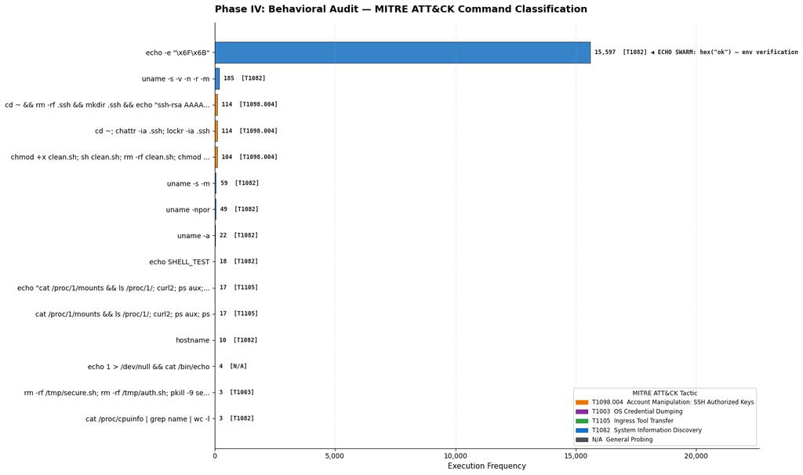

```
2026-04-12 02:01:19,553 - INFO - VirusTotal: API key not set — browse URLs generated, live checks skipped.
```

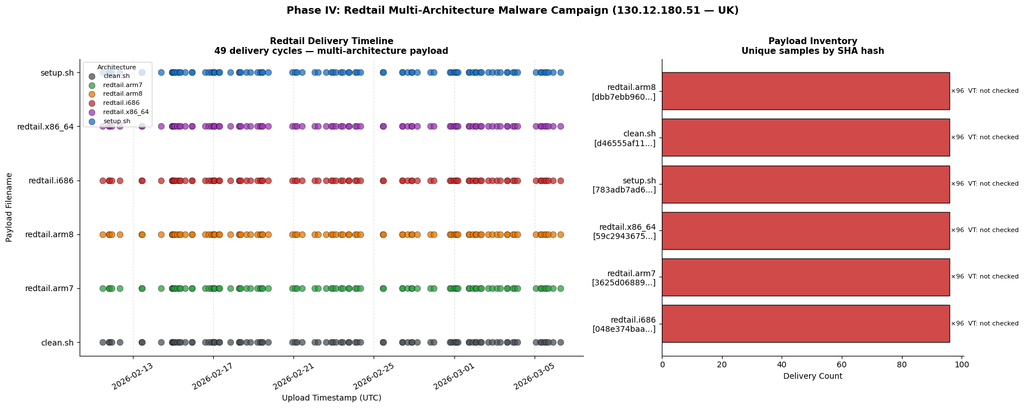

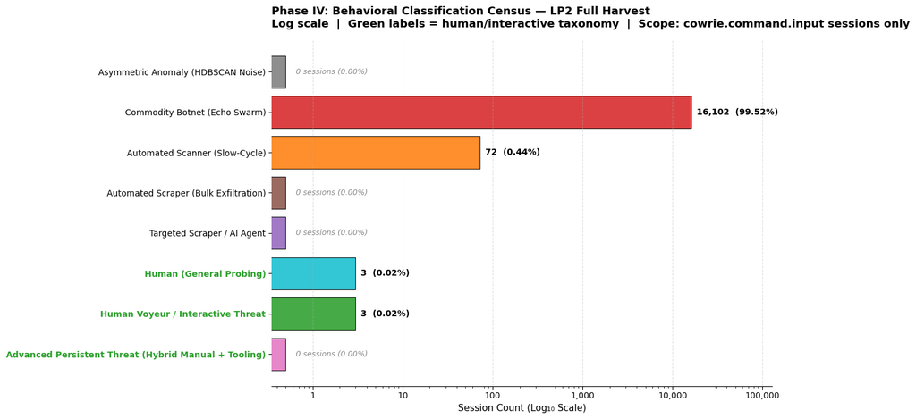

[figure not shown]

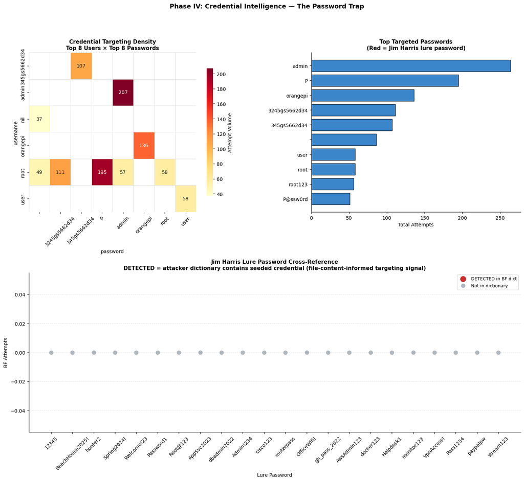

```
==========================================================================================
### PHASE IV: BEHAVIORAL ASSESSMENT COMPLETE ###
==========================================================================================
  COMMAND INTELLIGENCE (15 top commands):
    T1082        T1082 (Discovery)                              ×8
    T1098.004    T1098.004 (Persistence — SSH Auth Keys)        ×3
    T1105        T1105 (Execution/C2 — Tool Transfer)           ×2
    N/A          General Probing                                ×1
    T1003        T1003 (Credential Access)                      ×1
    Echo Swarm heartbeats: 1  |  Lure interactions: 0

  BEHAVIORAL CENSUS (16,180 sessions):
    Echo Swarm (botnet):  16,102  (99.52%)
    Human/Interactive:    6  (0.0371%)

  GEOGRAPHIC ATTRIBUTION (top 10 countries):
    Primary origin: China  (56.0% of verified events)

  MALWARE CAMPAIGN (Redtail — 130.12.180.51):
    Unique payloads:  6
    VT confirmed:     0 of 6 hashes (key not set — browse URLs only)
    [048e374baac36d8c...]  redtail.i686           ×96  Browse: https://www.virustotal.com/gui/file/048e374baac36d8cf68dd32e48313ef8eb517d647548b1bf5f26d2d0e2e3cdc7
    [3625d06889695359...]  redtail.arm7           ×96  Browse: https://www.virustotal.com/gui/file/3625d068896953595e75df328676a08bc071977ac1ff95d44b745bbcb7018c6f
    [59c29436755b0778...]  redtail.x86_64         ×96  Browse: https://www.virustotal.com/gui/file/59c29436755b0778e968d49feeae20ed65f5fa5e35f9f7965b8ed93420db91e5
    [783adb7ad6b16fe9...]  setup.sh               ×96  Browse: https://www.virustotal.com/gui/file/783adb7ad6b16fe9818f3e6d48b937c3ca1994ef24e50865282eeedeab7e0d59
    [d46555af1173d22f...]  clean.sh               ×96  Browse: https://www.virustotal.com/gui/file/d46555af1173d22f07c37ef9c1e0e74fd68db022f2b6fb3ab5388d2c5bc6a98e
    [dbb7ebb960dc0d5a...]  redtail.arm8           ×96  Browse: https://www.virustotal.com/gui/file/dbb7ebb960dc0d5a480f97ddde3a227a2d83fcaca7d37ae672e6a0a6785631e9

  CREDENTIAL INTELLIGENCE:
    Lure passwords in BF dictionary: 0 of 22
    Verdict: NULL — dictionary attacks are pre-baked, not file-content-informed
==========================================================================================
```

```python
    # Geographic
    if geo_df is not None and not geo_df.empty:
        top1 = geo_df.iloc[0]
        print(f'\n  GEOGRAPHIC ATTRIBUTION (top {len(geo_df)} countries):')
        print(f'    Primary origin: {top1["Country"]}  ({top1["Pct"]:.1f}% of verified events)')
        if REDTAIL_COUNTRY in geo_df['Country'].values:
            print(f'    NOTE: {REDTAIL_COUNTRY} volume includes Redtail campaign ({REDTAIL_SOURCE_IP})')

    # Malware
    if malware_df is not None and not malware_df.empty:
        vt_conf = malware_df[malware_df.get('vt_status', pd.Series()) == 'confirmed_malicious']
        print(f'\n  MALWARE CAMPAIGN (Redtail — {REDTAIL_SOURCE_IP}):')
        print(f'    Unique payloads:  {len(malware_df)}')
        print(f'    VT confirmed:     {len(vt_conf)} of {len(malware_df)} hashes '
              f'({("live" if VIRUSTOTAL_API_KEY else "key not set — browse URLs only")})')
        for _, r in malware_df.iterrows():
            vt = (f"VT: {r['vt_malicious']}/{r['vt_total']}"
                  if pd.notna(r.get('vt_malicious')) else f"Browse: {r.get('vt_url','N/A')}")
            print(f'    [{str(r["shasum"])[:16]}...]  {str(r["filename"]):<22} '
                  f'×{r["delivery_count"]}  {vt}')

    # Credentials
    if lure_xref is not None and not lure_xref.empty:
        detected = int(lure_xref['Detected'].sum())
        print(f'\n  CREDENTIAL INTELLIGENCE:')
        print(f'    Lure passwords in BF dictionary: {detected} of {len(lure_xref)}')
        verdict = ('HUMAN-INFORMED TARGETING DETECTED' if detected > 0
                   else 'NULL — dictionary attacks are pre-baked, not file-content-informed')
        print(f'    Verdict: {verdict}')

    print('=' * 90 + '\n')


# ─── EXECUTION ──────────────────────────────────────────────────────────────────

try:
    # 1. Command classification
    top_cmds_df = extract_top_commands(cmd_df, top_n=15)
    if top_cmds_df is not None:
        plot_tactical_command_audit(top_cmds_df)

    # 2. Malware campaign + VirusTotal
    malware_vt_df = enrich_malware_with_vt(malware_samples_df)
    if malware_vt_df is not None and not malware_vt_df.empty:
        plot_malware_campaign(malware_vt_df, upload_df)

    # 3. Behavioral census
    census_df = prepare_census_data(features_df)
    if census_df is not None:
        plot_attacker_census(census_df)

    # 4. Geographic attribution
    geo_df = prepare_geo_data(df)
    asn_df = prepare_asn_data(df, geo_df.iloc[0]['Country']) if geo_df is not None else None
    if geo_df is not None:
        plot_geo_threats(geo_df, asn_df)

    # 5. Credential intelligence
    pivot_df    = prepare_credential_pivot(top_creds)
    lure_xref_df = prepare_lure_cross_reference(top_creds)
    plot_credential_intelligence(pivot_df, top_creds, lure_xref_df)

    # Summary
    print_behavioral_summary(top_cmds_df, census_df, geo_df, lure_xref_df, malware_vt_df)

except NameError as e:
    logger.error('Missing upstream dependency: %s — ensure Phases I-III ran.', e)
```

## PHASE V: KEYSTROKE & BURST ANALYSIS

```python
# @title
# ==========================================
# PHASE V: KEYSTROKE & BURST ANALYSIS
# ==========================================
# Evaluates execution velocity across behavioral taxonomy groups to
# provide quantitative proof that ML classification reflects real
# timing differences between automated and human sessions.
#
# Thesis proof point: "Human vs bot behavioral separation is statistically defensible"
#
# Inputs:  cmd_df (Phase I — time_delta column), features_df (Phase III-B)
# Outputs: cadence_intel dict consumed by downstream phases

import logging
import pandas as pd
import numpy as np
import matplotlib.pyplot as plt
import matplotlib.ticker as mticker
import seaborn as sns
from typing import Optional, Dict, Any, List, Tuple

logger = logging.getLogger(__name__)

# ─── CONSTANTS ────────────────────────────────────────────────────────────────

MAX_DELTA_SECONDS       = 300
MACHINE_SPEED_THRESHOLD = 1.0
BOT_DOMINANCE_THRESHOLD = 80.0

# Cognitive Friction Threshold — DESIGN ASSUMPTION:
# Human reading speed for dense technical text: ~200-250 words/min.
# A typical Jim Harris lure file (passwords.txt ~350 words): ~1.5-2 min to read.
# 3.0s = minimum plausible inter-command delay for a human to:
#   (a) read a displayed file name or content snippet,
#   (b) evaluate whether it is worth pursuing, and
#   (c) formulate and type the next command.
# Sub-3s delays are consistent with scripted execution or clipboard-paste.
# Conservative threshold — minimizes false positives at cost of some false negatives.
COGNITIVE_FRICTION_THRESHOLD = 3.0

# Log-scale floor for axvspan xmin — hardcoded to avoid unreliable
# get_xlim() values on log-scaled axes before render completes.
LOG_SCALE_FLOOR = 1e-3


# ─── PHASE V-1: DATA PREPARATION ────────────────────────────────────────────

def prepare_cadence_data(
    cmd_df: pd.DataFrame,
    features_df: Optional[pd.DataFrame] = None,
    max_seconds: float = MAX_DELTA_SECONDS
) -> Tuple[Optional[pd.Series], Optional[pd.DataFrame]]:
    """
    Extracts inter-command timing deltas and joins ML behavioral labels.

    Echo Swarm sessions typically have only 1 command — they produce zero
    inter-command deltas and are absent from the delta distribution. This is
    explicitly documented: their absence reflects single-command nature,
    not a data quality issue.

    Args:
        cmd_df:      Master command telemetry DataFrame from Phase I.
        features_df: Session features with predicted_label from Phase III-B.
        max_seconds: Upper bound for valid deltas (outlier filter).

    Returns:
        Tuple: (cleaned delta Series for all traffic,
                enriched cmd_df with predicted_label for per-taxonomy analysis)
    """
    if cmd_df.empty or 'time_delta' not in cmd_df.columns:
        logger.error("CRITICAL: cmd_df missing 'time_delta' column.")
        return None, None

    enriched_cmd = cmd_df.copy()

    if features_df is not None and not features_df.empty \
            and 'predicted_label' in features_df.columns:
        label_map = features_df.set_index('session_id')['predicted_label']
        enriched_cmd['predicted_label'] = enriched_cmd['session'].map(label_map)
        n_labeled = enriched_cmd['predicted_label'].notna().sum()
        logger.info("Cadence enrichment: %d commands labeled from Phase III-B.", n_labeled)
    else:
        logger.warning(
            "features_df not provided — per-taxonomy cadence breakdown unavailable."
        )
        enriched_cmd['predicted_label'] = 'Unknown'

    valid = (
        enriched_cmd['time_delta']
        .dropna()
        .pipe(lambda s: s[(s > 0) & (s < max_seconds)])
    )

    if valid.empty:
        logger.warning(
            "No valid time deltas after filtering. "
            "Check that cmd_df has multi-command sessions."
        )
        return None, enriched_cmd

    return valid, enriched_cmd


def extract_human_cadence(
    enriched_cmd: pd.DataFrame,
    max_seconds: float = MAX_DELTA_SECONDS
) -> Optional[pd.Series]:
    """
    Extracts inter-command deltas for human-classified sessions only.

    The cognitive friction zone (>3s pauses) is analytically meaningful only
    in human sessions — bot scripts have fixed execution timing unrelated to
    content reading. Applying the threshold to the full dataset risks false
    positives from scripted pauses in slow-cycle automated scanners.

    Args:
        enriched_cmd: cmd_df with 'predicted_label' joined from Phase III-B.
        max_seconds:  Upper bound for valid deltas.

    Returns:
        pd.Series of human session deltas, or None if no human sessions found.
    """
    if 'predicted_label' not in enriched_cmd.columns:
        return None

    human_mask   = enriched_cmd['predicted_label'].isin(HUMAN_LABELS)
    human_cmds   = enriched_cmd[human_mask]

    if human_cmds.empty:
        logger.info("No human-classified commands found for friction zone analysis.")
        return None

    human_deltas = (
        human_cmds['time_delta']
        .dropna()
        .pipe(lambda s: s[(s > 0) & (s < max_seconds)])
    )

    return human_deltas if not human_deltas.empty else None


# ─── PHASE V-2: VISUALIZATION ───────────────────────────────────────────────

def plot_temporal_cadence(
    valid_cadence: pd.Series,
    human_cadence: Optional[pd.Series] = None,
    machine_threshold: float = MACHINE_SPEED_THRESHOLD,
    friction_threshold: float = COGNITIVE_FRICTION_THRESHOLD
) -> None:
    """
    Two-panel temporal cadence visualization.

    Left panel:  Full traffic distribution (all sessions).
                 Dominated by Echo Swarm machine-speed execution.

    Right panel: Human-classified sessions only (Phase III-B labels).
                 Cognitive friction zone shaded and annotated.
                 This panel is the empirical proof of human behavioral separation.

    Log-scaled X axis required — bot speeds (0.001s) and human speeds (1-60s)
    span 4+ orders of magnitude; linear scale renders human timing invisible.
```

```python
    Echo Swarm single-command sessions (15,597) produce zero inter-command
    deltas and are absent from both panels by definition, not data loss.
    """
    if valid_cadence is None or valid_cadence.empty:
        return

    has_human_panel = human_cadence is not None and not human_cadence.empty
    n_cols = 2 if has_human_panel else 1

    fig, axes = plt.subplots(
        1, n_cols,
        figsize=(18 if has_human_panel else 12, 7),
        sharey=False
    )
    if n_cols == 1:
        axes = [axes]

    # ── Left Panel: Full Traffic Distribution ───────────────────────────────
    ax1 = axes[0]

    sns.histplot(
        valid_cadence,
        bins=50,
        kde=True,
        color='#c92a2a',
        log_scale=True,
        edgecolor='black',
        alpha=0.75,
        ax=ax1,
        line_kws={'linewidth': 2}
    )

    ax1.axvline(
        x=machine_threshold,
        color='#1971c2',
        linestyle='--',
        linewidth=2.5,
        label=f'Machine threshold (< {machine_threshold}s)'
    )

    # FIXED: xmin hardcoded to LOG_SCALE_FLOOR (1e-3) — ax1.get_xlim()[0]
    # on a log-scaled axis returns an unreliable pre-render value. The prior
    # conditional guard was fragile and could still produce xmin <= 0.
    ax1.axvspan(
        xmin=LOG_SCALE_FLOOR,
        xmax=machine_threshold,
        color='#1971c2',
        alpha=0.07,
        label='Machine-speed zone'
    )

    ax1.set_title(
        'Full Traffic — All Sessions\n'
        f'(n={len(valid_cadence):,} valid deltas)',
        fontsize=12, fontweight='bold', pad=10
    )
    ax1.set_xlabel('Seconds Between Commands (Log₁₀ Scale)', fontsize=11)
    ax1.set_ylabel('Command Count (Density)', fontsize=11)
    ax1.legend(fontsize=9)
    ax1.grid(axis='y', linestyle='--', alpha=0.4)
    sns.despine(ax=ax1)

    # ── Right Panel: Human Sessions Only ────────────────────────────────────
    if has_human_panel:
        ax2 = axes[1]

        sns.histplot(
            human_cadence,
            bins=max(10, len(human_cadence) // 3),
            kde=len(human_cadence) >= 10,
            color='#2ca02c',
            log_scale=True,
            edgecolor='black',
            alpha=0.78,
            ax=ax2,
            line_kws={'linewidth': 2}
        )

        ax2.axvline(
            x=machine_threshold,
            color='#1971c2',
            linestyle='--',
            linewidth=2,
            label=f'Machine threshold ({machine_threshold}s)'
        )

        ax2.axvline(
            x=friction_threshold,
            color='#e67700',
            linestyle='-.',
            linewidth=2.5,
            label=f'Cognitive friction boundary ({friction_threshold}s)'
        )

        # Data-driven upper bound for friction zone shading
        x_upper = min(human_cadence.max() * 1.5, MAX_DELTA_SECONDS)
        ax2.axvspan(
            xmin=friction_threshold,
            xmax=x_upper,
            color='gold',
            alpha=0.18,
            label=(
                f'Cognitive friction zone (> {friction_threshold}s)\n'
                f'Consistent with file reading / decision latency'
            )
        )

        friction_count = int((human_cadence >= friction_threshold).sum())
        friction_pct   = friction_count / len(human_cadence) * 100

        ax2.text(
            0.97, 0.95,
            f"Friction zone hits: {friction_count}\n"
            f"({friction_pct:.1f}% of human deltas)\n"
            f"Threshold: {friction_threshold}s\n"
            f"(design assumption — see code)",
            transform=ax2.transAxes,
            fontsize=9,
            va='top', ha='right',
            bbox=dict(boxstyle='round,pad=0.5', facecolor='lightyellow',
                      edgecolor='#e67700', alpha=0.9)
        )

        ax2.set_title(
            f'Human-Classified Sessions Only\n'
            f'(n={len(human_cadence):,} deltas, '
            f'{len(HUMAN_LABELS)} taxonomy categories)',
            fontsize=12, fontweight='bold', pad=10
        )
        ax2.set_xlabel('Seconds Between Commands (Log₁₀ Scale)', fontsize=11)
        ax2.set_ylabel('Command Count (Density)', fontsize=11)
        ax2.legend(fontsize=8.5, loc='upper left')
        ax2.grid(axis='y', linestyle='--', alpha=0.4)
        sns.despine(ax=ax2)

    fig.suptitle(
        'Phase V: Temporal Cadence Audit — Execution Velocity & Cognitive Friction\n'
        'Left: Full traffic (bot-dominated)  |  '
        'Right: Human sessions only (ML-filtered)',
        fontsize=14, fontweight='bold'
    )
    # FIXED: rect=[0, 0, 1, 0.96] reserves space for suptitle — eliminates
    # UserWarning from tight_layout when suptitle y > figure boundary.
    plt.tight_layout(rect=[0, 0, 1, 0.96])
    plt.show()


# ─── PHASE V-3: STATISTICAL ASSESSMENT ──────────────────────────────────────

def evaluate_cadence_intel(
    valid_cadence: pd.Series,
    enriched_cmd: Optional[pd.DataFrame] = None,
    human_cadence: Optional[pd.Series] = None,
    machine_threshold: float = MACHINE_SPEED_THRESHOLD,
    friction_threshold: float = COGNITIVE_FRICTION_THRESHOLD
) -> Dict[str, Any]:
    """
    Computes cadence statistics across the full dataset and per-taxonomy groups.

    Per-taxonomy statistics are the quantitative proof that ML behavioral
    labels correspond to measurably different timing populations — the
    empirical foundation of the "separation is statistically defensible"
    thesis claim.
    """
    total  = len(valid_cadence)
    mach_n = int((valid_cadence < machine_threshold).sum())
    fric_n = int((valid_cadence >= friction_threshold).sum())

    intel = {
        "total_deltas":   total,
        "machine_hits":   mach_n,
        "human_hits":     total - mach_n,
        "friction_hits":  fric_n,
        "machine_ratio":  mach_n / total * 100 if total > 0 else 0.0,
        "human_ratio":    (total - mach_n) / total * 100 if total > 0 else 0.0,
        "friction_ratio": fric_n / total * 100 if total > 0 else 0.0,
        "mean_cadence":   float(valid_cadence.mean()),
        "median_cadence": float(valid_cadence.median()),
        "std_cadence":    float(valid_cadence.std()),
        "p95_cadence":    float(valid_cadence.quantile(0.95)),
        "taxonomy_breakdown": {}
    }
```